# R Notebook

# Prepare data

## import mapping data

```r
coverage_total_reduced=read.table(file = "../TABLES/coverage_filtered.txt")
dim(coverage_total_reduced)
```

```
## [1] 5382  112
```

```r
head(coverage_total_reduced)
```

|  | A.ruf.tab_Ige_2012_Sept_WGA | Tricho_Ige_2012_Sept_WGA | D.mel_Gotheron_2012_Sept_WGA | D.sim_Gotheron_2012_Sept_WGA | D.sub_Gotheron_2012_Sept_WGA | D.suz_Gotheron_2012_Sept_WGA | D.im_Gotheron_2012_Sept_WGA | L.h_Gotheron_2012_Sept_WGA | L.b_Gotheron_2012_Sept_WGA | Tricho_Gotheron_2012_Sept_WGA | Pachy_Gotheron_2012_Sept_WGA | D.im_Gotheron_2012_Sept_WGAbis | H2O__NA__WGA | D.mel_Ige_2011_Juin_WTA | D.im_Ige_2011_Juin_WTA | D.sub.obs_Ige_2011_Juin_WTA | L.h_Ige_2011_Juin_WTA | D.mel_Gotheron_2011_Juin_WTA | D.im_Gotheron_2011_Juin_WTA | D.hyd_Gotheron_2011_Juin_WTA | D.suz_Gotheron_2011_Juin_WTA | L.h_Gotheron_2011_Juin_WTA | L.b_Gotheron_2011_Juin_WTA | D.mel_Ige_2011_Sept_WTA | D.sim_Ige_2011_Sept_WTA | D.im_Ige_2011_Sept_WTA | D.sub.obs_Ige_2011_Sept_WTA | D.suz_Ige_2011_Sept_WTA | D.kuntzei_Ige_2011_Sept_WTA | … |
| --- | --- | --- | --- | --- | --- | --- | --- | --- | --- | --- | --- | --- | --- | --- | --- | --- | --- | --- | --- | --- | --- | --- | --- | --- | --- | --- | --- | --- | --- | --- |
| contig_1 | 0.128494 | 0.260595 | 0.000000 | 0.000000 | 0 | 0 | 0 | 0.0676285 | 0.784040 | 0.413436 | 0.2777280 | 0.081605 | 0 | 0 | 0 | 0 | 0 | 0 | 0.0671776 | 0 | 0 | 0.0392245 | 0 | 0.0901713 | 0 | 0 | 0 | 0 | 0 | … |
| contig_10 | 0.000000 | 0.000000 | 0.000000 | 0.000000 | 0 | 0 | 0 | 0.0000000 | 0.000000 | 0.000000 | 0.0395137 | 0.000000 | 0 | 0 | 0 | 0 | 0 | 0 | 0.0000000 | 0 | 0 | 0.0000000 | 0 | 0.0000000 | 0 | 0 | 0 | 0 | 0 | … |
| contig_10003 | 0.000000 | 0.000000 | 0.000000 | 0.000000 | 0 | 0 | 0 | 0.0000000 | 0.000000 | 0.000000 | 0.0000000 | 0.000000 | 0 | 0 | 0 | 0 | 0 | 0 | 0.0000000 | 0 | 0 | 0.0000000 | 0 | 0.0000000 | 0 | 0 | 0 | 0 | 0 | … |
| contig_10005 | 0.000000 | 0.000000 | 0.000000 | 0.000000 | 0 | 0 | 0 | 0.0000000 | 0.107035 | 0.000000 | 0.0000000 | 0.000000 | 0 | 0 | 0 | 0 | 0 | 0 | 0.0000000 | 0 | 0 | 0.0000000 | 0 | 0.0000000 | 0 | 0 | 0 | 0 | 0 | … |
| contig_1001 | 0.000000 | 0.000000 | 0.000000 | 0.000000 | 0 | 0 | 0 | 0.0000000 | 0.000000 | 0.000000 | 0.0000000 | 0.000000 | 0 | 0 | 0 | 0 | 0 | 0 | 0.0000000 | 0 | 0 | 0.0000000 | 0 | 0.0000000 | 0 | 0 | 0 | 0 | 0 | … |
| contig_10016 | 0.000000 | 0.000000 | 0.170878 | 0.467509 | 0 | 0 | 0 | 0.1774970 | 0.000000 | 0.000000 | 0.0000000 | 0.000000 | 0 | 0 | 0 | 0 | 0 | 0 | 0.0000000 | 0 | 0 | 0.0000000 | 0 | 0.0000000 | 0 | 0 | 0 | 0 | 0 | … |

## import taxonomic assignation

```r
# import taxonomy dataset for the union of all contigs
taxo=read.table(file = "../TABLES/taxo_info2.txt", sep="\t", h=T, comment.char = "", quote = "")
taxo=taxo[rownames(taxo) %in% rownames(coverage_total_reduced),]
taxo$family=as.factor(taxo$family)

# modify editing errors
levels(x = taxo$family)[38]="Unclassified DNA viruses"
levels(x = taxo$family)[40]="Unclassified RNA viruses"
levels(x = taxo$family)[41]="Unclassified viruses"
levels(x = taxo$family)[42]="Unclassified viruses"

head(taxo)
```

|  | species | genus | family | superkingdom | evalue | alnlen | pident |
| --- | --- | --- | --- | --- | --- | --- | --- |
| contig_1 | Mycobacterium_phage_PegLeg | Bongovirus | Siphoviridae | Viruses | 1.970e-62 | 1425 | 0.317 |
| contig_10 | Candidatus_Wolbachia_massiliensis | Wolbachia | Anaplasmataceae | Bacteria | 4.344e-38 | 240 | 0.762 |
| contig_1001 | NA | NA | Enterobacteriaceae | Bacteria | 2.086e-155 | 1284 | 0.588 |
| contig_10016 | NA | Wolbachia | Anaplasmataceae | Bacteria | 2.238e-186 | 873 | 0.996 |
| contig_10017 | Kwi_virus | NA | Unclassified RNA viruses | Viruses | 5.850e-212 | 1428 | 0.665 |
| contig_10024 | NA | NA | Enterobacteriaceae | Bacteria | 4.174e-133 | 1080 | 0.589 |

```r
dim(taxo)
```

```
## [1] 4796    7
```

the difference with the dim(coverage_total_reduced) is due to the fact that some contigs had no hits at all in the initial blastx.

## import sequence and add contig length

```r
library(Biostrings)
seqs=readBStringSet("../assembly/B+C_subsampling+WGTA/assembly.fasta")
length(seqs)
```

```
## [1] 23182
```

```r
seqs_length=data.frame(width(seqs), names(seqs))
rownames(seqs_length)=seqs_length$names.seqs.
# append sequ length to taxo info
taxo2=merge(x = taxo, y=seqs_length , by="row.names", all.x=T)
row.names(taxo2)=taxo2$Row.names
taxo=taxo2[, -which(names(taxo2) == "Row.names")]
taxo=taxo[, -which(names(taxo) == "names.seqs.")]
names(taxo)[8]="seqs_length"
dim(taxo)
```

```
## [1] 4796    8
```

```r
head(taxo)
```

|  | species | genus | family | superkingdom | evalue | alnlen | pident | seqs_length |
| --- | --- | --- | --- | --- | --- | --- | --- | --- |
| contig_1 | Mycobacterium_phage_PegLeg | Bongovirus | Siphoviridae | Viruses | 1.970e-62 | 1425 | 0.317 | 2218 |
| contig_10 | Candidatus_Wolbachia_massiliensis | Wolbachia | Anaplasmataceae | Bacteria | 4.344e-38 | 240 | 0.762 | 1645 |
| contig_1001 | NA | NA | Enterobacteriaceae | Bacteria | 2.086e-155 | 1284 | 0.588 | 9793 |
| contig_10016 | NA | Wolbachia | Anaplasmataceae | Bacteria | 2.238e-186 | 873 | 0.996 | 1662 |
| contig_10017 | Kwi_virus | NA | Unclassified RNA viruses | Viruses | 5.850e-212 | 1428 | 0.665 | 1662 |
| contig_10024 | NA | NA | Enterobacteriaceae | Bacteria | 4.174e-133 | 1080 | 0.589 | 1661 |

## Append taxonomic info to mapping info

merge the tables

```r
coverage_total_reduced=merge(x = coverage_total_reduced, y = taxo, by="row.names", all.x=T, all.y=F)
rownames(coverage_total_reduced)=coverage_total_reduced$Row.names
coverage_total_reduced=coverage_total_reduced[,-which(colnames(coverage_total_reduced)=="Row.names")]
dim(coverage_total_reduced)
```

```
## [1] 5382  120
```

```r
head(coverage_total_reduced)
```

|  | A.ruf.tab_Ige_2012_Sept_WGA | Tricho_Ige_2012_Sept_WGA | D.mel_Gotheron_2012_Sept_WGA | D.sim_Gotheron_2012_Sept_WGA | D.sub_Gotheron_2012_Sept_WGA | D.suz_Gotheron_2012_Sept_WGA | D.im_Gotheron_2012_Sept_WGA | L.h_Gotheron_2012_Sept_WGA | L.b_Gotheron_2012_Sept_WGA | Tricho_Gotheron_2012_Sept_WGA | Pachy_Gotheron_2012_Sept_WGA | D.im_Gotheron_2012_Sept_WGAbis | H2O__NA__WGA | D.mel_Ige_2011_Juin_WTA | D.im_Ige_2011_Juin_WTA | D.sub.obs_Ige_2011_Juin_WTA | L.h_Ige_2011_Juin_WTA | D.mel_Gotheron_2011_Juin_WTA | D.im_Gotheron_2011_Juin_WTA | D.hyd_Gotheron_2011_Juin_WTA | D.suz_Gotheron_2011_Juin_WTA | L.h_Gotheron_2011_Juin_WTA | L.b_Gotheron_2011_Juin_WTA | D.mel_Ige_2011_Sept_WTA | D.sim_Ige_2011_Sept_WTA | D.im_Ige_2011_Sept_WTA | D.sub.obs_Ige_2011_Sept_WTA | D.suz_Ige_2011_Sept_WTA | D.kuntzei_Ige_2011_Sept_WTA | … |
| --- | --- | --- | --- | --- | --- | --- | --- | --- | --- | --- | --- | --- | --- | --- | --- | --- | --- | --- | --- | --- | --- | --- | --- | --- | --- | --- | --- | --- | --- | --- |
| contig_1 | 0.128494 | 0.260595 | 0.000000 | 0.000000 | 0 | 0 | 0 | 0.0676285 | 0.784040 | 0.413436 | 0.2777280 | 0.081605 | 0 | 0 | 0 | 0 | 0 | 0 | 0.0671776 | 0 | 0 | 0.0392245 | 0 | 0.0901713 | 0 | 0 | 0 | 0 | 0 | … |
| contig_10 | 0.000000 | 0.000000 | 0.000000 | 0.000000 | 0 | 0 | 0 | 0.0000000 | 0.000000 | 0.000000 | 0.0395137 | 0.000000 | 0 | 0 | 0 | 0 | 0 | 0 | 0.0000000 | 0 | 0 | 0.0000000 | 0 | 0.0000000 | 0 | 0 | 0 | 0 | 0 | … |
| contig_10003 | 0.000000 | 0.000000 | 0.000000 | 0.000000 | 0 | 0 | 0 | 0.0000000 | 0.000000 | 0.000000 | 0.0000000 | 0.000000 | 0 | 0 | 0 | 0 | 0 | 0 | 0.0000000 | 0 | 0 | 0.0000000 | 0 | 0.0000000 | 0 | 0 | 0 | 0 | 0 | … |
| contig_10005 | 0.000000 | 0.000000 | 0.000000 | 0.000000 | 0 | 0 | 0 | 0.0000000 | 0.107035 | 0.000000 | 0.0000000 | 0.000000 | 0 | 0 | 0 | 0 | 0 | 0 | 0.0000000 | 0 | 0 | 0.0000000 | 0 | 0.0000000 | 0 | 0 | 0 | 0 | 0 | … |
| contig_1001 | 0.000000 | 0.000000 | 0.000000 | 0.000000 | 0 | 0 | 0 | 0.0000000 | 0.000000 | 0.000000 | 0.0000000 | 0.000000 | 0 | 0 | 0 | 0 | 0 | 0 | 0.0000000 | 0 | 0 | 0.0000000 | 0 | 0.0000000 | 0 | 0 | 0 | 0 | 0 | … |
| contig_10016 | 0.000000 | 0.000000 | 0.170878 | 0.467509 | 0 | 0 | 0 | 0.1774970 | 0.000000 | 0.000000 | 0.0000000 | 0.000000 | 0 | 0 | 0 | 0 | 0 | 0 | 0.0000000 | 0 | 0 | 0.0000000 | 0 | 0.0000000 | 0 | 0 | 0 | 0 | 0 | … |

## Prepare data

We will split in WGA and WTA samples

```r
# WGA

wga_cov=coverage_total_reduced[,grepl("WGA", names(coverage_total_reduced))]
# append the corresponding negative control
wga_cov$control=coverage_total_reduced$H2O__NA__WGA
# and taxo information
n_cols=dim(coverage_total_reduced)[2]
wga_cov=cbind(wga_cov, coverage_total_reduced[,c((n_cols-7): n_cols)])
dim(wga_cov)
```

```
## [1] 5382   65
```

remove contigs or genomes not sufficiently covered (<0.25) in this subset of samples (WGA) append max

```r
n_cols=dim(wga_cov)[2]
wga_cov$max=apply(X = wga_cov[, 1:(n_cols-8)], MARGIN = 1, max)
wga_cov2=wga_cov[wga_cov$max>=0.25,]
wga_cov2$max=NULL
dim(wga_cov2)
```

```
## [1] 1358   65
```

We will split in WGA and WTA samples

```r
# WTA

wta_cov=coverage_total_reduced[,grepl("WTA", names(coverage_total_reduced))]
# append the corresponding negative control
wta_cov$control=coverage_total_reduced$H2O__NA__WTA
# and taxo information
n_cols=dim(coverage_total_reduced)[2]
wta_cov=cbind(wta_cov, coverage_total_reduced[,c((n_cols-7): n_cols)])
dim(wta_cov)
```

```
## [1] 5382   65
```

remove contigs or genomes not sufficiently covered (<0.25) in this subset of samples (WtA) append max

```r
n_cols=dim(wta_cov)[2]
wta_cov$max=apply(X = wta_cov[, 1:(n_cols-8)], MARGIN = 1, max)
wta_cov2=wta_cov[wta_cov$max>=0.25,]
wta_cov2$max=NULL
dim(wta_cov2)
```

```
## [1] 281  65
```

## What’s inside?

how many contigs with virus homolog ?

```r
t=table(wga_cov2$superkingdom, exclude ="")
names(t)[is.na(names(t))]="NA"
barplot(table(wga_cov2$superkingdom,exclude =""), names.arg = names(t), las=3)
```

[figure not shown]

```r
t=table(wta_cov2$superkingdom, exclude ="")
names(t)[is.na(names(t))]="NA"
barplot(table(wta_cov2$superkingdom,exclude =""), names.arg = names(t), las=3)
```

[figure not shown]

## Remove phages and retrotransposons, and polydnaviruses

Since we are interested in insect viruses, let’s remove the phages https://en.wikipedia.org/wiki/Bacteriophage and retrotransposons

```r
phage_families=read.table("../TABLES/phage_families.txt", h=FALSE)
# missing Herelleviridae
phage_families=phage_families$V1
phage_families=c(phage_families, "Herelleviridae", "Plectroviridae")
# retrotransposons + Polydnaviruses
retro_transposons=c("Belpaoviridae", "Metaviridae", "Pseudoviridae", "Polydnaviridae")
phage_retrotransposons=c(phage_families,retro_transposons )

wga_cov2=wga_cov2[-which(wga_cov2$family %in% phage_retrotransposons),]

# further remove the contigs with no family assignation but having species name containing "phage"
if (length(grep("phage", wga_cov2$species))>0){
wga_cov2=wga_cov2[-grep("phage", wga_cov2$species),]
}

dim(wga_cov2)
```

```
## [1] 1263   65
```

same for wta

```r
wta_cov2=wta_cov2[-which(wta_cov2$family %in% phage_retrotransposons),]
# further remove the contigs with no family assignation but having species name containing "phage"
if (length(grep("phage", wta_cov2$species))>0){
wta_cov2=wta_cov2[-grep("phage", wta_cov2$species),]
}
dim(wta_cov2)
```

```
## [1] 280  65
```

## Focus on putative viruses

First filter for viruses only (based on best blast hit)

for WGA

```r
wga_cov2_viruses=wga_cov2[which(wga_cov2$superkingdom=="Viruses"),]
```

```r
dim(wga_cov2_viruses)
```

```
## [1] 136  65
```

Simplify naming for unclassified viruses :

```r
wga_cov2_viruses$family[grep(pattern = "Unclassif", x = wga_cov2_viruses$family)]="Unclassified viruses"
```

for WTA

```r
wta_cov2_viruses=wta_cov2[which(wta_cov2$superkingdom=="Viruses"),]
```

```r
dim(wta_cov2_viruses)
```

```
## [1] 147  65
```

Simplify naming for unclassified viruses :

```r
wta_cov2_viruses$family[grep(pattern = "Unclassif", x = wta_cov2_viruses$family)]="Unclassified viruses"
```

Subset to expected virus families only

```r
# official list of virus species from ICTV 2020
ictv=read.table("../TABLES/ICTV\ Master\ Species\ List\ 2020.v1.txt", header = TRUE, sep="\t", comment.char = "")
head(ictv)
```

|  | Sort | Realm | Subrealm | Kingdom | Subkingdom | Phylum | Subphylum | Class | Subclass | Order | Suborder | Family | Subfamily | Genus | Subgenus | Species | Genome.Composition | Last.Change | MSL.of.Last.Change | Proposal.for.Last.Change | Taxon.History.URL | X |
| --- | --- | --- | --- | --- | --- | --- | --- | --- | --- | --- | --- | --- | --- | --- | --- | --- | --- | --- | --- | --- | --- | --- |
| 1 | 1 | Adnaviria | NA | Zilligvirae | NA | Taleaviricota |  | Tokiviricetes | NA | Ligamenvirales |  | Lipothrixviridae |  | Alphalipothrixvirus |  | Alphalipothrixvirus SBFV2 | dsDNA | Moved, | 36 | 2020.186B.R.Adnaviria.zip | ICTVonline=202008644 | NA |
| 2 | 2 | Adnaviria | NA | Zilligvirae | NA | Taleaviricota |  | Tokiviricetes | NA | Ligamenvirales |  | Lipothrixviridae |  | Alphalipothrixvirus |  | Alphalipothrixvirus SFV1 | dsDNA | Moved,Removed as Type Species, | 36 | 2020.001G.R.Abolish_type_species.pdf | ICTVonline=202008643 | NA |
| 3 | 3 | Adnaviria | NA | Zilligvirae | NA | Taleaviricota |  | Tokiviricetes | NA | Ligamenvirales |  | Lipothrixviridae |  | Betalipothrixvirus |  | Acidianus filamentous virus 3 | dsDNA | Moved, | 36 | 2020.186B.R.Adnaviria.zip | ICTVonline=202001532 | NA |
| 4 | 4 | Adnaviria | NA | Zilligvirae | NA | Taleaviricota |  | Tokiviricetes | NA | Ligamenvirales |  | Lipothrixviridae |  | Betalipothrixvirus |  | Acidianus filamentous virus 6 | dsDNA | Moved, | 36 | 2020.186B.R.Adnaviria.zip | ICTVonline=202001533 | NA |
| 5 | 5 | Adnaviria | NA | Zilligvirae | NA | Taleaviricota |  | Tokiviricetes | NA | Ligamenvirales |  | Lipothrixviridae |  | Betalipothrixvirus |  | Acidianus filamentous virus 7 | dsDNA | Moved, | 36 | 2020.186B.R.Adnaviria.zip | ICTVonline=202001534 | NA |
| 6 | 6 | Adnaviria | NA | Zilligvirae | NA | Taleaviricota |  | Tokiviricetes | NA | Ligamenvirales |  | Lipothrixviridae |  | Betalipothrixvirus |  | Acidianus filamentous virus 8 | dsDNA | Moved, | 36 | 2020.186B.R.Adnaviria.zip | ICTVonline=202001535 | NA |

```r
dim(ictv)
```

```
## [1] 9110   22
```

Filter on genomic structure :

```r
genomic_structures=unique(ictv$Genome.Composition)
genomic_structures
```

```
##  [1] "dsDNA"        "ssDNA(+)"     "ssDNA"        "ssDNA(+/-)"   "dsDNA; ssDNA"
##  [6] "dsRNA"        "ssRNA(+)"     "ssRNA"        "ssRNA(-)"     "ssRNA(+/-)"
## [11] "dsDNA-RT"     "ssRNA-RT"     "ssDNA(-)"
```

```r
DNA_viruses=genomic_structures[grep(pattern = "DNA", genomic_structures)]
RNA_viruses=genomic_structures[grep(pattern = "RNA", genomic_structures)]
```

```r
DNA_viruses_families=c(unique(ictv[which(ictv$Genome.Composition %in% DNA_viruses),]$Family), "LbFV-like", "Unclassified DNA viruses", "Parvoviridae")
DNA_viruses_families[order(DNA_viruses_families)]
```

```
##  [1] ""                         "Ackermannviridae"
##  [3] "Adenoviridae"             "Adintoviridae"
##  [5] "Alloherpesviridae"        "Alphasatellitidae"
##  [7] "Ampullaviridae"           "Anelloviridae"
##  [9] "Ascoviridae"              "Asfarviridae"
## [11] "Autographiviridae"        "Autolykiviridae"
## [13] "Bacilladnaviridae"        "Baculoviridae"
## [15] "Bicaudaviridae"           "Bidnaviridae"
## [17] "Caulimoviridae"           "Chaseviridae"
## [19] "Circoviridae"             "Clavaviridae"
## [21] "Corticoviridae"           "Demerecviridae"
## [23] "Drexlerviridae"           "Finnlakeviridae"
## [25] "Fuselloviridae"           "Geminiviridae"
## [27] "Genomoviridae"            "Globuloviridae"
## [29] "Guelinviridae"            "Guttaviridae"
```

[output cut: 26 more lines]

```r
RNA_viruses_families=c(unique(ictv[which(ictv$Genome.Composition %in% RNA_viruses),]$Family), "Unclassified dsRNA viruses", "Unclassified RNA viruses", "Picornavirales")
RNA_viruses_families[order(RNA_viruses_families)]
```

```
##   [1] ""                           "Abyssoviridae"
##   [3] "Aliusviridae"               "Alphaflexiviridae"
##   [5] "Alphatetraviridae"          "Alvernaviridae"
##   [7] "Amalgaviridae"              "Amnoonviridae"
##   [9] "Arenaviridae"               "Arteriviridae"
##  [11] "Artoviridae"                "Aspiviridae"
##  [13] "Astroviridae"               "Atkinsviridae"
##  [15] "Avsunviroidae"              "Barnaviridae"
##  [17] "Belpaoviridae"              "Benyviridae"
##  [19] "Betaflexiviridae"           "Birnaviridae"
##  [21] "Blumeviridae"               "Bornaviridae"
##  [23] "Botourmiaviridae"           "Bromoviridae"
##  [25] "Caliciviridae"              "Carmotetraviridae"
##  [27] "Chrysoviridae"              "Chuviridae"
##  [29] "Closteroviridae"            "Coronaviridae"
```

[output cut: 43 more lines]

Filter WGA (remove RNA viruses)

```r
wga_cov2_viruses=wga_cov2_viruses[-which(wga_cov2_viruses$family %in% RNA_viruses_families),]
dim(wga_cov2_viruses)
```

```
## [1] 63 65
```

Filter WTA (remove DNA viruses)

```r
wta_cov2_viruses=wta_cov2_viruses[-which(wta_cov2_viruses$family %in% DNA_viruses_families),]
```

```r
dim(wta_cov2_viruses)
```

```
## [1] 139  65
```

```r
wga_cov2_viruses$family=factor(wga_cov2_viruses$family) # drop unused levels
```

```r
wta_cov2_viruses$family=factor(wta_cov2_viruses$family) # drop unused levels
```

## Create a table containing viruses and unassigned

in order to detect unassigned contigs that may be part of virus genomes (dark matter…), we include the unassigned contigs.

wga :

```r
wga_unassigned=wga_cov2[which(is.na(wga_cov2$superkingdom)),]
wga_cov2_viruses_plus_unassigned=rbind(wga_cov2_viruses,wga_unassigned)
dim(wga_cov2_viruses_plus_unassigned)
```

```
## [1] 267  65
```

A few have blast hits but were not assigned to a a tax id.

```r
# they have no taxonomy associated
suspect = wga_cov2_viruses_plus_unassigned[is.na(wga_cov2_viruses_plus_unassigned$superkingdom),]
# but do have a e-value
suspect2 = suspect[-which(is.na(suspect$evalue)),]
dim(suspect2)
```

```
## [1] 17 65
```

Check their ids :

```r
rownames(suspect2)
```

```
##  [1] "contig_11046" "contig_12058" "contig_1335"  "contig_1484"  "contig_15364"
##  [6] "contig_1560"  "contig_18075" "contig_1889"  "contig_2048"  "contig_21403"
## [11] "contig_22238" "contig_4928"  "contig_5707"  "contig_5958"  "contig_8495"
## [16] "contig_9174"  "contig_9628"
```

need to look at the blast output:

```r
blastx=read.csv("../TABLES/all_taxonomy.blastx", sep = ";", header = T)
blastx[blastx$query %in% rownames(suspect2),]
```

|  | query | target | pident | alnlen | mismatch | gapopen | qstart | qend | tstart | tend | evalue | bits | tlen | Taxid | species | species_subgroup | species_group | subgenus | genus | tribe | subfamily | family | superfamily | no_rank | clade | infraorder | suborder | order | cohort | … |
| --- | --- | --- | --- | --- | --- | --- | --- | --- | --- | --- | --- | --- | --- | --- | --- | --- | --- | --- | --- | --- | --- | --- | --- | --- | --- | --- | --- | --- | --- | --- |
| 2496 | contig_22238 | WP_001295345.1 | 0.514 | 735 | 120 | 0 | 55193 | 54459 | 7 | 254 | 1.011e-67 | 234 | NA | 91347 | NA | NA | NA | NA | NA | NA | NA | NA | NA | cellular_organisms | NA | NA | NA | Enterobacterales | NA | … |
| 2497 | contig_22238 | WP_001295345.1 | 0.514 | 735 | 120 | 0 | 55193 | 54459 | 7 | 254 | 1.011e-67 | 234 | NA | 91347 | NA | NA | NA | NA | NA | NA | NA | NA | NA | cellular_organisms | NA | NA | NA | Enterobacterales | NA | … |
| 2498 | contig_22238 | WP_001295345.1 | 0.514 | 735 | 120 | 0 | 55193 | 54459 | 7 | 254 | 1.011e-67 | 234 | NA | 91347 | NA | NA | NA | NA | NA | NA | NA | NA | NA | cellular_organisms | NA | NA | NA | Enterobacterales | NA | … |
| 6927 | contig_1335 | XP_022234698.1 | 0.292 | 1908 | 450 | 0 | 5245 | 3338 | 55 | 690 | 4.391e-74 | 271 | NA | NA | NA | NA | NA | NA | NA | NA | NA | NA | NA | NA | NA | NA | NA | NA | NA | … |
| 6928 | contig_1335 | XP_022234667.1 | 0.405 | 681 | 134 | 0 | 4018 | 3338 | 312 | 538 | 9.119e-50 | 197 | NA | NA | NA | NA | NA | NA | NA | NA | NA | NA | NA | NA | NA | NA | NA | NA | NA | … |
| 6929 | contig_1335 | XP_022212061.1 | 0.392 | 681 | 137 | 0 | 4018 | 3338 | 312 | 538 | 1.663e-48 | 193 | NA | NA | NA | NA | NA | NA | NA | NA | NA | NA | NA | NA | NA | NA | NA | NA | NA | … |
| 7829 | contig_1484 | XP_022225209.1 | 0.646 | 2781 | 325 | 0 | 1571 | 4351 | 1 | 919 | 0.000e+00 | 1250 | NA | NA | NA | NA | NA | NA | NA | NA | NA | NA | NA | NA | NA | NA | NA | NA | NA | … |
| 7830 | contig_1484 | XP_022225210.1 | 0.663 | 2496 | 277 | 0 | 1571 | 4066 | 1 | 823 | 0.000e+00 | 1147 | NA | NA | NA | NA | NA | NA | NA | NA | NA | NA | NA | NA | NA | NA | NA | NA | NA | … |
| 7831 | contig_1484 | XP_022210549.1 | 0.674 | 543 | 59 | 0 | 3524 | 4066 | 1 | 181 | 1.694e-68 | 263 | NA | NA | NA | NA | NA | NA | NA | NA | NA | NA | NA | NA | NA | NA | NA | NA | NA | … |
| 8345 | contig_15364 | XP_022234296.1 | 0.443 | 426 | 79 | 0 | 670 | 245 | 3 | 144 | 6.626e-29 | 118 | NA | NA | NA | NA | NA | NA | NA | NA | NA | NA | NA | NA | NA | NA | NA | NA | NA | … |

[output cut: 803 more lines]

```r
wga_cov2_viruses_plus_unassigned=wga_cov2_viruses_plus_unassigned[-which(rownames(wga_cov2_viruses_plus_unassigned) %in% rownames(suspect2)),]
```

wta :

```r
wta_unassigned=wta_cov2[which(is.na(wta_cov2$superkingdom)),]
wta_cov2_viruses_plus_unassigned=rbind(wta_cov2_viruses,wta_unassigned)
dim(wta_cov2_viruses_plus_unassigned)
```

```
## [1] 223  65
```

Add sequence length for the unassigned contigs :

```r
#wga:
wga_cov2_viruses_plus_unassigned=cbind(wga_cov2_viruses_plus_unassigned[,-which(names(wga_cov2_viruses_plus_unassigned)=="seqs_length")], seqs_length[,"width.seqs."][match(rownames(wga_cov2_viruses_plus_unassigned), rownames(seqs_length))])
names(wga_cov2_viruses_plus_unassigned)[dim(wga_cov2_viruses_plus_unassigned)[2]]="seqs_length"

# two contigs were not correctly assigned
wga_cov2_viruses_plus_unassigned["contig_18555",]$family="Parvoviridae"
wga_cov2_viruses_plus_unassigned["contig_15192",]$family="Parvoviridae"


#wta:
wta_cov2_viruses_plus_unassigned=cbind(wta_cov2_viruses_plus_unassigned[,-which(names(wta_cov2_viruses_plus_unassigned)=="seqs_length")], seqs_length[,"width.seqs."][match(rownames(wta_cov2_viruses_plus_unassigned), rownames(seqs_length))])
names(wta_cov2_viruses_plus_unassigned)[dim(wta_cov2_viruses_plus_unassigned)[2]]="seqs_length"
```

# Heatmap plots

## Write functions to plot

```r
library(plyr)
```

```r
library(RColorBrewer)
library(ComplexHeatmap)
library(circlize)
plot_heatmap=function(mymatrix=wga_cov2_viruses, pdf="test.pdf", name="coverage", colcex=3, rowcex=3, min=0.2, max=1, cluster_rows=TRUE, row_order=NA, cluster_cols=TRUE, col_order=NA, row_title="", show_heatmap_legend=TRUE, show_annotation_name=TRUE, colour_code_viruses=d){

  # dimension of the matrix
  ncols=dim(mymatrix)[2]

  # order rows according to something ?
if (cluster_rows){
  cluster_rows=TRUE
  print ("no special row order")
}
if (cluster_rows==FALSE){
  print ("Fixed row order")
  cluster_rows=FALSE
  mymatrix=mymatrix[row_order,]
}
  # extract virus taxonomy info
  taxo=mymatrix[, c((ncols-7):ncols)]

# define the form of names for viruses (rows)
mymatrix$pident=mymatrix$pident*100 #round the percent identity for blastx results
#mymatrix$identity[is.na(mymatrix$identity)]="~100" # to indicate that these are very similar to known viral genomic sequences
# define row labels
short_names=sub(pattern = "contig_", replacement = "c", rownames(mymatrix))
labels=paste(mymatrix$species, paste0(mymatrix$pident, "%"), mymatrix$seqs_length, short_names, sep=" ")

# order cols according to something ?
if (cluster_cols){
  cluster_cols=TRUE
  print ("no special cols order")
}
if (cluster_cols==FALSE){
  print ("Fixed cols order")
  cluster_cols=FALSE
  mymatrix=mymatrix[,col_order]
}


# define colour scheme
col_fun = colorRamp2(c(min, max), c("green", "red"))

# define annotation colors for cols
rows_annotation=strsplit(colnames(mymatrix)[1:(ncols-9)], split = "_", fixed = T)
rows_annotation=do.call(rbind.data.frame,rows_annotation)
names(rows_annotation)=c("species", "location", "year", "season", "libtype")
# to deal with the duplicated sample (D im taken as D. phalerat)
#rows_annotation$libtype[rows_annotation$species=="control"]="WGA"

if (sum(rows_annotation$libtype=="WGAbis")>0){
rows_annotation$libtype[rows_annotation$libtype=="WGAbis"]="WGA"
rows_annotation[rows_annotation$species=="H2O",]=c(NA, NA, NA, NA, "WGA")
}
if (sum(rows_annotation$libtype=="WTAbis")>0){
rows_annotation$libtype[rows_annotation$libtype=="WTAbis"]="WTA"
rows_annotation[rows_annotation$species=="H2O",]=c(NA, NA, NA, NA, "WTA")
}

colnames(mymatrix)[grepl("H2O",colnames(mymatrix))]="neg_control"

rows_annotation$season=as.factor(rows_annotation$season)
#levels(rows_annotation$season)=c(NA,"June", "Sept")
levels(rows_annotation$season)[levels(rows_annotation$season)=="Juin"]="June"
levels(rows_annotation$season)[levels(rows_annotation$season)=="Sept"]="Sept"
#levels(rows_annotation$season)[levels(rows_annotation$season)=="Sept"]="Sept"
#rows_annotation$season=factor(rows_annotation$season)
rows_annotation$year=factor(rows_annotation$year)
rows_annotation$location=factor(rows_annotation$location)
rows_annotation$species=factor(rows_annotation$species)
# reorder columns
rows_annotation=rows_annotation[,c(4,3,2,1)]

# define species colors
cols_ha=c(brewer.pal(3, "Set1"),brewer.pal(12, "Set3"))
col_lb=cols_ha[1]
cols_ha[1]=cols_ha[12]
cols_ha[12]=col_lb
names(cols_ha)=c("A.ruf.tab" , "C.amo"  ,   "D.hyd"  ,   "D.im"    ,  "D.kuntzei" , "D.mel"   ,   "D.pha"  ,    "D.sim" ,    "D.sub"  ,   "D.sub.obs" , "D.suz"  ,   "L.b"    ,   "L.h"    ,   "Pachy"   ,  "Tricho" )

ha = HeatmapAnnotation(df = rows_annotation,
                       col = list(season=c("Sept"="darkgrey", "June"="lightgrey"),
                                  year=c("2011"="lightgrey", "2012"="darkgrey"),
                                  location=c("Ige"="lightgrey", "Gotheron"="darkgrey"),
                                  species=cols_ha),
                       na_col = "white")


# define colour annotation for rows

cols_hb=colour_code_viruses$colour
names(cols_hb)=colour_code_viruses$Family
cols_hb=as.factor(cols_hb)

# reduce to viruses families that are present in the samples
viruses_actually_present=unique(taxo$family)
cols_hb=cols_hb[which(names(cols_hb) %in% viruses_actually_present)]
mymatrix$family=factor(mymatrix$family)

hb= rowAnnotation(family = taxo$family, col= list(family=cols_hb), show_annotation_name = show_annotation_name)


# heatmap
figure=Heatmap(as.matrix(mymatrix[, 1:(ncols-9)]), name = name, # name that appears above the legend scale
                        col=col_fun,  # function for mapping colours to the main data
                        rect_gp = gpar(col="white", lwd=0.4), # add white arround each cell
                        #clustering_distance_rows = function(x, y) 1 - cor(x, y), # define distance for rows
                        #clustering_distance_columns = function(x, y) 1 - cor(x, y) # define distance for cols
                        row_labels = labels,
                        clustering_method_rows = "complete", # define the clustering method
                        clustering_method_columns = "ward.D2", #ward.D2
                        column_names_gp = gpar(fontsize = colcex), # define col label size
                        row_names_gp = gpar(fontsize = rowcex), # define col label size
                        top_annotation = ha,
                        cluster_rows = cluster_rows,
                        cluster_columns= cluster_cols,
                        right_annotation = hb,
                        row_names_max_width = unit(10, "cm"),
                        row_title = row_title,
                        show_heatmap_legend =show_heatmap_legend,
                        row_title_rot = 0,
                        )

#figure=Heatmap(as.matrix(mymatrix[, 1:(ncols-6)]), name=name, cluster_rows=TRUE, clustering_method_rows = "complete", col=col_fun,rect_gp = gpar(col="white", lwd=0.4), row_labels = labels, cluster_columns = FALSE)

pdf(paste0("../figures/", pdf), width=10, height=10)
draw(figure)
dev.off()

return(figure)
return("done")
}
```

## Apply the plot function

WGA

Chaq virus is most likely an RNA virus, and contig_13461 (found in D. hydei and assigned to Cedratvirus) is rather a Spiroplasma protein. so let’s remove them from the WGA figure :

```
## [1] "no special row order"
## [1] "no special cols order"
```

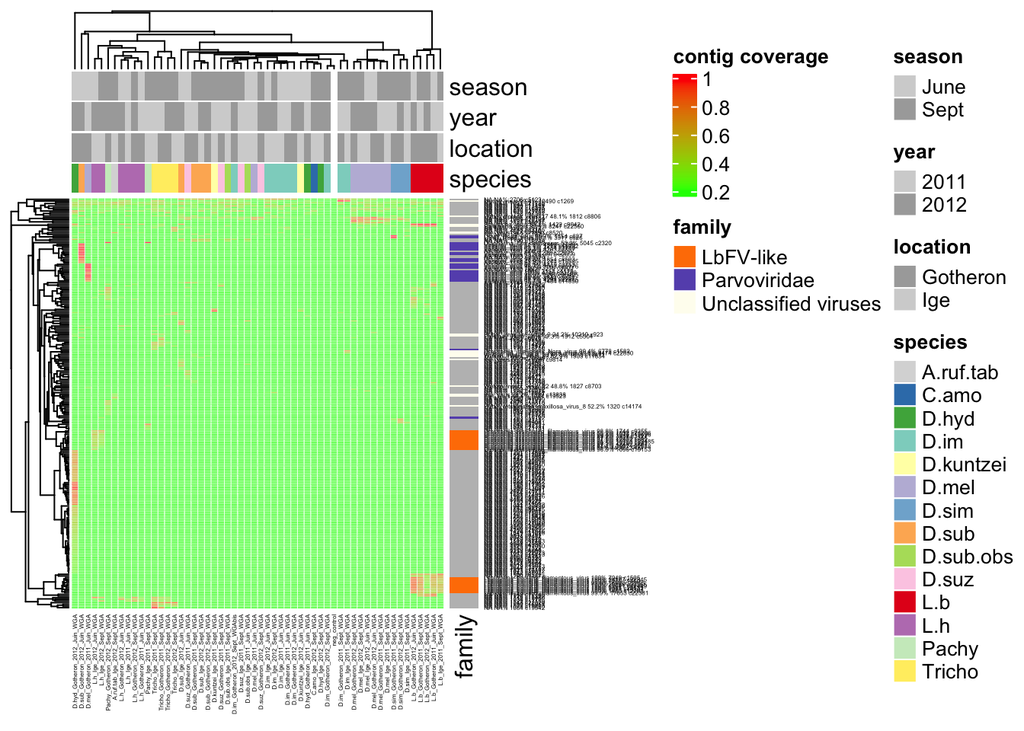

```r
wga_cov2_viruses_plus_unassigned_clean=wga_cov2_viruses_plus_unassigned[-which(wga_cov2_viruses_plus_unassigned$species=="Chaq_virus" | wga_cov2_viruses_plus_unassigned$species=="Cedratvirus_A11"),]

#levels(wga_cov2_viruses_plus_unassigned_clean$family)=c(levels(wga_cov2_viruses_plus_unassigned_clean$family), "Unassigned viruses")
#wga_cov2_viruses_plus_unassigned_clean$family[is.na(wga_cov2_viruses_plus_unassigned_clean$family)]="Unassigned viruses"

write.table(wga_cov2_viruses_plus_unassigned_clean, file = "../TABLES/wga_cov2_viruses_plus_unassigned_clean.txt", row.names = TRUE, col.names = TRUE, sep="\t", quote=FALSE)

d=read.table("../TABLES/colour_code_virus_families.txt", h=T, sep="\t", comment.char = "")
plot_heatmap(mymatrix=wga_cov2_viruses_plus_unassigned_clean, pdf="heatmap_cov_wga2_with_unassigned.pdf", name="contig coverage", colour_code_viruses = d)
```

WTA

```
## [1] "no special row order"
## [1] "no special cols order"
```

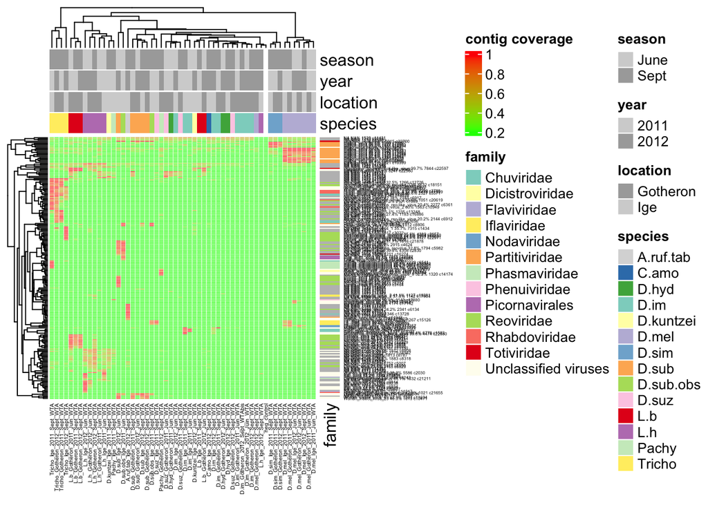

```r
write.table(wta_cov2_viruses_plus_unassigned, file = "../TABLES/wta_cov2_viruses_plus_unassigned.txt", row.names = TRUE, col.names = TRUE, sep="\t", quote=FALSE)

plot_heatmap(mymatrix=wta_cov2_viruses_plus_unassigned, pdf="heatmap_cov_wta2_plus_unassigned.pdf", name="contig coverage", rowcex = 3, colcex=4, colour_code_viruses = d)
```

## output sequences

Write sequences for each dataset

```r
seqs_wga=seqs[row.names(wga_cov2_viruses_plus_unassigned_clean)]
```

```r
seqs_wta=seqs[row.names(wta_cov2_viruses_plus_unassigned)]
```

```r
length(seqs_wga)
```

```
## [1] 246
```

```r
length(seqs_wta)
```

```
## [1] 223
```

```r
unassigned_sequences_names=unique(c(rownames(wga_unassigned), rownames(wta_unassigned)))
length(unassigned_sequences_names)
```

```
## [1] 242
```

```r
unassigned_sequences=seqs[unassigned_sequences_names]
```

```r
writeXStringSet(seqs_wga, filepath = "../sequences/wga_final_contigs_with_unassigned.fa")
```

```r
writeXStringSet(seqs_wta, filepath = "../sequences/wta_final_contigs_with_unassigned.fa")
```

```r
width(unassigned_sequences)
```

```
##   [1]   1659   1643   1624   1616   1610   1572   1554   1549   1549   1544
##  [11]   1528   1526   1520   1518   1516   1510   1509   1034   1140   1486
##  [21]   1482   1474   1471   1469   1458   1445   1442   1428   1428   1423
##  [31]   1420   1398   1397   1396   1395   1394   1102   1386   7731   1055
##  [41]   1331   1321   1304   1302   1301   1293   1292   1291   7109   1280
##  [51]   1269   1267   1263   1255   1253   1252   1247   6870   1240   1231
##  [61]   1231   1230   1226   1225   1221   1207   1190   1190   1188   1186
##  [71]   1182   1181   6454   1180   1175   1174   1122   1169   1165   1163
##  [81]   1162   1157   1156   1156   1153   1151   1148   1147   1146   1136
##  [91]   1135   1131   1126   1121   1120   1119   1118   1116   1110   1107
## [101]   1105   5911   1102   1100   1100   1095   1084   1082   1079   1075
## [111]   1074   1073   1065   1062   1055   5549   1053   1052   1052   1050
## [121]   1044   1039   1038   1037   1035   1034   1034   1163   1033   1031
## [131]   1031   1030   1027   1023   1020   1018   1018   1015   1013   1013
## [141]   1013   1011   1009 113827   2371   2148   4659   4108   3918   3699
## [151]   3644   3302   3269   3253   3110   3065   3025   2861   2825   2797
## [161]   2783   2766   2721   2706   2598   2484   2391   2359   1100   2180
## [171]   2096   2073   2053   1122   2024   2022   1681   1696   1991   1958
## [181]   1547   1881   1871   1861   1861   1855   1842   1830   1817   1800
## [191]   1789   1770   1765   1763   1761   1759   1753   1048   1744   1627
## [201]   1711   1710   1682   1666   1644   1643   1638   1565   1532   1511
## [211]   1398   1384   1372   1329   1285   1281   1262   1245   1217   1216
## [221]   1212   1162   1151   1148   1130   1083   1077   1062   1060   1056
## [231]   3812   2945   2876   2772   2359   2289   2032   2031   2018   1897
## [241]   1809   1781
```

```r
unassigned_sequences[which(max(width(unassigned_sequences))==width(unassigned_sequences))]
```

```
## BStringSet object of length 1:
##      width seq                                              names
## [1] 113827 AAAGTGCCTTGTCCCCCGGACAA...CTGACGCTGACACTGCAAATGC contig_22238
```

```r
# contig_4567 has no orf and is also removed because it takes hours in the orf prediction script
unassigned_sequences_names=unassigned_sequences_names[-which(unassigned_sequences_names %in% c("contig_22238", "contig_4567"))]
unassigned_sequences=seqs[unassigned_sequences_names]
writeXStringSet(unassigned_sequences, filepath = "../sequences/final_contigs_unassigned_wgta.fa")
```

# Second round of blastx (mmseqs2) on unassigned sequences using whole nr db

```r
mmseqs2_unassigned=read.table("../TABLES/final_contigs_unassigned_wgta_blastx.m8", sep="\t", comment.char = "", quote = "")
names(mmseqs2_unassigned)=c("query","target","pident","alnlen","qcov","mismatch","gapopen","qstart","qend","tstart","tend","evalue","bits","tlen","taxid","taxname","taxlineage")
dim(mmseqs2_unassigned)
```

```
## [1] 42192    17
```

```r
# some sequences were forgotten :
mmseqs2_unassigned2=read.table("../TABLES/final_contigs_unassigned_wgta_blastx2.m8", sep="\t", comment.char = "", quote = "")
names(mmseqs2_unassigned2)=c("query","target","pident","alnlen","qcov","mismatch","gapopen","qstart","qend","tstart","tend","evalue","bits","tlen","taxid","taxname","taxlineage")
dim(mmseqs2_unassigned2)
```

```
## [1] 5420   17
```

```r
mmseqs2_unassigned=rbind(mmseqs2_unassigned, mmseqs2_unassigned2)
dim(mmseqs2_unassigned)
```

```
## [1] 47612    17
```

```r
head(mmseqs2_unassigned)
```

|  | query | target | pident | alnlen | qcov | mismatch | gapopen | qstart | qend | tstart | tend | evalue | bits | tlen | taxid | taxname | taxlineage |
| --- | --- | --- | --- | --- | --- | --- | --- | --- | --- | --- | --- | --- | --- | --- | --- | --- | --- |
| 1 | contig_2972 | WP_127093139.1 | 86.4 | 558 | 0.136 | 25 | 0 | 1362 | 1919 | 1 | 186 | 1.816e-101 | 335 | 389 | 2138 | Spiroplasma poulsonii | -_cellular organisms;d_Bacteria;-_Terrabacteria group;p_Tenericutes;c_Mollicutes;o_Entomoplasmatales;f_Spiroplasmataceae;g_Spiroplasma;s_Spiroplasma poulsonii |
| 2 | contig_2972 | WP_040093897.1 | 86.0 | 558 | 0.136 | 26 | 0 | 1362 | 1919 | 1 | 186 | 6.414e-101 | 334 | 389 | 2138 | Spiroplasma poulsonii | -_cellular organisms;d_Bacteria;-_Terrabacteria group;p_Tenericutes;c_Mollicutes;o_Entomoplasmatales;f_Spiroplasmataceae;g_Spiroplasma;s_Spiroplasma poulsonii |
| 3 | contig_2972 | WP_070407038.1 | 78.0 | 558 | 0.136 | 41 | 0 | 1362 | 1919 | 1 | 186 | 9.944e-89 | 299 | 389 | 2637901 | unclassified Spiroplasma | -_cellular organisms;d_Bacteria;-_Terrabacteria group;p_Tenericutes;c_Mollicutes;o_Entomoplasmatales;f_Spiroplasmataceae;g_Spiroplasma;-_unclassified Spiroplasma |
| 4 | contig_2972 | WP_040093899.1 | 91.6 | 435 | 0.106 | 12 | 0 | 685 | 1119 | 191 | 335 | 2.626e-83 | 280 | 380 | 2138 | Spiroplasma poulsonii | -_cellular organisms;d_Bacteria;-_Terrabacteria group;p_Tenericutes;c_Mollicutes;o_Entomoplasmatales;f_Spiroplasmataceae;g_Spiroplasma;s_Spiroplasma poulsonii |
| 5 | contig_2972 | WP_127093138.1 | 89.2 | 435 | 0.106 | 16 | 0 | 685 | 1119 | 191 | 335 | 1.989e-80 | 272 | 380 | 2138 | Spiroplasma poulsonii | -_cellular organisms;d_Bacteria;-_Terrabacteria group;p_Tenericutes;c_Mollicutes;o_Entomoplasmatales;f_Spiroplasmataceae;g_Spiroplasma;s_Spiroplasma poulsonii |
| 6 | contig_2972 | WP_004027700.1 | 69.9 | 558 | 0.136 | 56 | 0 | 1362 | 1919 | 1 | 186 | 2.878e-76 | 263 | 387 | 2134 | Spiroplasma melliferum | -_cellular organisms;d_Bacteria;-_Terrabacteria group;p_Tenericutes;c_Mollicutes;o_Entomoplasmatales;f_Spiroplasmataceae;g_Spiroplasma;s_Spiroplasma melliferum |

```r
tail(mmseqs2_unassigned)
```

|  | query | target | pident | alnlen | qcov | mismatch | gapopen | qstart | qend | tstart | tend | evalue | bits | tlen | taxid | taxname | taxlineage |
| --- | --- | --- | --- | --- | --- | --- | --- | --- | --- | --- | --- | --- | --- | --- | --- | --- | --- |
| 47607 | contig_20236 | HAA83744.1 | 85.9 | 75 | 0.071 | 3 | 0 | 988 | 1062 | 180 | 204 | 0.0003910 | 47 | 205 | 1741 | Thermodesulfobacterium commune | -_cellular organisms;d_Bacteria;p_Thermodesulfobacteria;c_Thermodesulfobacteria;o_Thermodesulfobacteriales;f_Thermodesulfobacteriaceae;g_Thermodesulfobacterium;s_Thermodesulfobacterium commune |
| 47608 | contig_20236 | HAA81081.1 | 85.9 | 75 | 0.071 | 3 | 0 | 988 | 1062 | 225 | 249 | 0.0003910 | 47 | 250 | 1755 | Thermoanaerobacter sp. | -_cellular organisms;d_Bacteria;-_Terrabacteria group;p_Firmicutes;c_Clostridia;o_Thermoanaerobacterales;f_Thermoanaerobacteraceae;g_Thermoanaerobacter;-_unclassified Thermoanaerobacter;s_Thermoanaero… |
| 47609 | contig_20236 | CUT07922.1 | 87.0 | 72 | 0.068 | 3 | 0 | 989 | 1060 | 222 | 245 | 0.0004595 | 46 | 260 | 1633631 | Candidatus Kryptonium thompsoni | -_cellular organisms;d_Bacteria;-_FCB group;p_Candidatus Kryptonia;g_Candidatus Kryptonium;s_Candidatus Kryptonium thompsoni |
| 47610 | contig_20236 | KID53127.1 | 91.4 | 75 | 0.071 | 2 | 0 | 1060 | 986 | 1 | 25 | 0.0007171 | 50 | 93 | 1386084 | Neisseria meningitidis LNP27256 | -_cellular organisms;d_Bacteria;p_Proteobacteria;c_Betaproteobacteria;o_Neisseriales;f_Neisseriaceae;g_Neisseria;s_Neisseria meningitidis;-_Neisseria meningitidis LNP27256 |
| 47611 | contig_20236 | AJZ87475.1 | 46.5 | 150 | 0.141 | 27 | 0 | 913 | 1062 | 269 | 319 | 0.0007416 | 46 | 321 | 1188315 | Streptomyces sp. AgN23 | -_cellular organisms;d_Bacteria;-_Terrabacteria group;p_Actinobacteria;c_Actinobacteria;o_Streptomycetales;f_Streptomycetaceae;g_Streptomyces;-_unclassified Streptomyces;s_Streptomyces sp. AgN23 |
| 47612 | contig_20236 | SGZ41845.1 | 87.7 | 72 | 0.068 | 3 | 0 | 988 | 1059 | 421 | 444 | 0.0007416 | 46 | 470 | 56406 | Hanseniaspora guilliermondii | -_cellular organisms;d_Eukaryota;-_Opisthokonta;k_Fungi;-_Dikarya;p_Ascomycota;-_saccharomyceta;-_Saccharomycotina;c_Saccharomycetes;o_Saccharomycetales;f_Saccharomycodaceae;g_Hanseniaspora;s_Hansenia… |

identify non viral sequences

```r
library(dplyr)
# remove non significant alignements
mmseqs2_unassigned= filter(mmseqs2_unassigned, evalue<10e-10)
mmseqs2_unassigned= filter(mmseqs2_unassigned, alnlen>150)
# select the smallest evalue for each query (group)
mmseqs2_unassigned_besthit = mmseqs2_unassigned %>% group_by(query) %>% arrange(evalue) %>% dplyr::slice(1)
mmseqs2_unassigned_besthit
```

| query | target | pident | alnlen | qcov | mismatch | gapopen | qstart | qend | tstart | tend | evalue | bits | tlen | taxid | taxname | taxlineage |
| --- | --- | --- | --- | --- | --- | --- | --- | --- | --- | --- | --- | --- | --- | --- | --- | --- |
| contig_10044 | WP_127092741.1 | 97.6 | 345 | 0.208 | 3 | 0 | 129 | 473 | 36 | 150 | 1.134e-69 | 239 | 363 | 2138 | Spiroplasma poulsonii | -_cellular organisms;d_Bacteria;-_Terrabacteria group;p_Tenericutes;c_Mollicutes;o_Entomoplasmatales;f_Spiroplasmataceae;g_Spiroplasma;s_Spiroplasma poulsonii |
| contig_10174 | EEZ7036673.1 | 92.7 | 240 | 0.146 | 6 | 0 | 581 | 820 | 1 | 80 | 3.922e-42 | 158 | 80 | 562 | Escherichia coli | -_cellular organisms;d_Bacteria;p_Proteobacteria;c_Gammaproteobacteria;o_Enterobacterales;f_Enterobacteriaceae;g_Escherichia;s_Escherichia coli |
| contig_10445 | WP_011225092.1 | 85.2 | 492 | 0.304 | 24 | 0 | 494 | 3 | 190 | 353 | 6.858e-87 | 291 | 504 | 47834 | Spiroplasma kunkelii | -_cellular organisms;d_Bacteria;-_Terrabacteria group;p_Tenericutes;c_Mollicutes;o_Entomoplasmatales;f_Spiroplasmataceae;g_Spiroplasma;s_Spiroplasma kunkelii |
| contig_11046 | WP_042485639.1 | 92.1 | 819 | 0.527 | 21 | 0 | 681 | 1499 | 1 | 273 | 1.751e-166 | 528 | 273 | 511 | Alcaligenes faecalis | -_cellular organisms;d_Bacteria;p_Proteobacteria;c_Betaproteobacteria;o_Burkholderiales;f_Alcaligenaceae;g_Alcaligenes;s_Alcaligenes faecalis |
| contig_11098 | WP_127092662.1 | 92.2 | 417 | 0.269 | 11 | 0 | 221 | 637 | 142 | 280 | 3.848e-80 | 271 | 564 | 2138 | Spiroplasma poulsonii | -_cellular organisms;d_Bacteria;-_Terrabacteria group;p_Tenericutes;c_Mollicutes;o_Entomoplasmatales;f_Spiroplasmataceae;g_Spiroplasma;s_Spiroplasma poulsonii |
| contig_11099 | WP_167874505.1 | 86.3 | 387 | 0.250 | 18 | 0 | 332 | 718 | 62 | 190 | 4.459e-66 | 233 | 190 | 2735351 | Ochrobactrum sp. MC-1LL | -_cellular organisms;d_Bacteria;p_Proteobacteria;c_Alphaproteobacteria;o_Rhizobiales;f_Brucellaceae;g_Ochrobactrum;-_unclassified Ochrobactrum;s_Ochrobactrum sp. MC-1LL |
| contig_11146 | XP_024889700.1 | 91.5 | 207 | 0.134 | 6 | 0 | 317 | 111 | 24 | 92 | 3.582e-34 | 134 | 92 | 300111 | Temnothorax curvispinosus | -_cellular organisms;d_Eukaryota;-_Opisthokonta;k_Metazoa;-_Eumetazoa;-_Bilateria;-_Protostomia;-_Ecdysozoa;-_Panarthropoda;p_Arthropoda;-_Mandibulata;-_Pancrustacea;-_Hexapoda;c_Insecta;-_Dicondylia;… |
| contig_11337 | AJQ51849.1 | 88.6 | 687 | 0.450 | 26 | 0 | 308 | 994 | 1 | 229 | 1.909e-131 | 424 | 343 | 369822 | Rickettsia raoultii | -_cellular organisms;d_Bacteria;p_Proteobacteria;c_Alphaproteobacteria;o_Rickettsiales;f_Rickettsiaceae;-_Rickettsieae;g_Rickettsia;-_spotted fever group;s_Rickettsia raoultii |
| contig_11431 | PTB83434.1 | 92.2 | 180 | 0.118 | 5 | 0 | 1502 | 1323 | 2 | 61 | 1.732e-28 | 118 | 61 | 206403 | Sulfurovum lithotrophicum | -_cellular organisms;d_Bacteria;p_Proteobacteria;-_delta/epsilon subdivisions;c_Epsilonproteobacteria;o_Campylobacterales;f_Sulfurovaceae;g_Sulfurovum;s_Sulfurovum lithotrophicum |
| contig_11463 | WP_040093366.1 | 99.1 | 471 | 0.310 | 1 | 0 | 617 | 147 | 1 | 157 | 1.286e-100 | 331 | 293 | 2138 | Spiroplasma poulsonii | -_cellular organisms;d_Bacteria;-_Terrabacteria group;p_Tenericutes;c_Mollicutes;o_Entomoplasmatales;f_Spiroplasmataceae;g_Spiroplasma;s_Spiroplasma poulsonii |

[output cut: 155 more lines]

Which ones are likely to be viral, based on this new blastx (first hit only)?

```r
t1=mmseqs2_unassigned_besthit[grep(pattern = "virus", x = mmseqs2_unassigned_besthit$taxlineage),]
t1
```

| query | target | pident | alnlen | qcov | mismatch | gapopen | qstart | qend | tstart | tend | evalue | bits | tlen | taxid | taxname | taxlineage |
| --- | --- | --- | --- | --- | --- | --- | --- | --- | --- | --- | --- | --- | --- | --- | --- | --- |
| contig_14483 | QNS31042.1 | 28.2 | 555 | 0.426 | 133 | 0 | 744 | 1298 | 228 | 413 | 3.646e-11 | 79 | 1032 | 2771483 | Thrips tabaci associated reovirus 1 | d_Viruses;-_Riboviria;k_Orthornavirae;p_Duplornaviricota;c_Resentoviricetes;o_Reovirales;f_Reoviridae;-_unclassified Reoviridae;s_Thrips tabaci associated reovirus 1 |
| contig_15192 | AWV66983.1 | 41.7 | 870 | 0.689 | 166 | 0 | 871 | 2 | 3 | 288 | 9.327e-56 | 213 | 458 | 2050976 | Ambidensovirus sp. | d_Viruses;-_Monodnaviria;k_Shotokuvirae;p_Cossaviricota;c_Quintoviricetes;o_Piccovirales;f_Parvoviridae;-_Densovirinae;g_Ambidensovirus;-_unclassified Densovirus;s_Ambidensovirus sp. |
| contig_17370 | QNS17458.1 | 36.3 | 1155 | 0.994 | 247 | 0 | 1155 | 1 | 2 | 389 | 3.677e-63 | 234 | 1331 | 2771463 | Serbia reo-like virus 1 | d_Viruses;-_Riboviria;k_Orthornavirae;p_Duplornaviricota;c_Resentoviricetes;o_Reovirales;f_Reoviridae;-_unclassified Reoviridae;s_Serbia reo-like virus 1 |
| contig_17755 | APG79147.1 | 39.6 | 981 | 0.855 | 196 | 0 | 3 | 983 | 1 | 325 | 3.596e-60 | 224 | 328 | 1922996 | Hubei odonate virus 15 | d_Viruses;-_Riboviria;-_unclassified Riboviria;-_unclassified RNA viruses ShiM-2016;s_Hubei odonate virus 15 |
| contig_18555 | AWV66983.1 | 41.6 | 549 | 0.492 | 105 | 0 | 564 | 16 | 3 | 183 | 1.138e-30 | 136 | 458 | 2050976 | Ambidensovirus sp. | d_Viruses;-_Monodnaviria;k_Shotokuvirae;p_Cossaviricota;c_Quintoviricetes;o_Piccovirales;f_Parvoviridae;-_Densovirinae;g_Ambidensovirus;-_unclassified Densovirus;s_Ambidensovirus sp. |
| contig_4957 | APG79174.1 | 23.2 | 2622 | 0.946 | 685 | 0 | 2623 | 2 | 298 | 1190 | 1.129e-65 | 256 | 1217 | 1922881 | Hubei diptera virus 20 | d_Viruses;-_Riboviria;-_unclassified Riboviria;-_unclassified RNA viruses ShiM-2016;s_Hubei diptera virus 20 |
| contig_6072 | APG79146.1 | 22.2 | 2316 | 0.982 | 603 | 0 | 2323 | 8 | 82 | 857 | 2.504e-49 | 204 | 905 | 1922996 | Hubei odonate virus 15 | d_Viruses;-_Riboviria;-_unclassified Riboviria;-_unclassified RNA viruses ShiM-2016;s_Hubei odonate virus 15 |
| contig_6311 | APG79145.1 | 33.0 | 1482 | 0.647 | 330 | 0 | 2287 | 806 | 140 | 633 | 3.267e-67 | 259 | 896 | 1922996 | Hubei odonate virus 15 | d_Viruses;-_Riboviria;-_unclassified Riboviria;-_unclassified RNA viruses ShiM-2016;s_Hubei odonate virus 15 |

same thing on all hits that pass the evalue and alnlength filters :

```r
t2=mmseqs2_unassigned[grep(pattern = "virus", x = mmseqs2_unassigned$taxlineage),]
t2
```

|  | query | target | pident | alnlen | qcov | mismatch | gapopen | qstart | qend | tstart | tend | evalue | bits | tlen | taxid | taxname | taxlineage |
| --- | --- | --- | --- | --- | --- | --- | --- | --- | --- | --- | --- | --- | --- | --- | --- | --- | --- |
| 10599 | contig_18555 | AWV66983.1 | 41.6 | 549 | 0.492 | 105 | 0 | 564 | 16 | 3 | 183 | 1.138e-30 | 136 | 458 | 2050976 | Ambidensovirus sp. | d_Viruses;-_Monodnaviria;k_Shotokuvirae;p_Cossaviricota;c_Quintoviricetes;o_Piccovirales;f_Parvoviridae;-_Densovirinae;g_Ambidensovirus;-_unclassified Densovirus;s_Ambidensovirus sp. |
| 12344 | contig_14483 | QNS31042.1 | 28.2 | 555 | 0.426 | 133 | 0 | 744 | 1298 | 228 | 413 | 3.646e-11 | 79 | 1032 | 2771483 | Thrips tabaci associated reovirus 1 | d_Viruses;-_Riboviria;k_Orthornavirae;p_Duplornaviricota;c_Resentoviricetes;o_Reovirales;f_Reoviridae;-_unclassified Reoviridae;s_Thrips tabaci associated reovirus 1 |
| 16064 | contig_4827 | QHA33694.1 | 32.7 | 576 | 0.204 | 129 | 0 | 1859 | 2434 | 32 | 224 | 8.169e-19 | 102 | 429 | 2689361 | Chibugado virus | d_Viruses;-_Riboviria;k_Pararnavirae;p_Artverviricota;c_Revtraviricetes;o_Ortervirales;f_Metaviridae;-_unclassified Metaviridae;s_Chibugado virus |
| 20447 | contig_15192 | AWV66983.1 | 41.7 | 870 | 0.689 | 166 | 0 | 871 | 2 | 3 | 288 | 9.327e-56 | 213 | 458 | 2050976 | Ambidensovirus sp. | d_Viruses;-_Monodnaviria;k_Shotokuvirae;p_Cossaviricota;c_Quintoviricetes;o_Piccovirales;f_Parvoviridae;-_Densovirinae;g_Ambidensovirus;-_unclassified Densovirus;s_Ambidensovirus sp. |
| 24672 | contig_4957 | APG79174.1 | 23.2 | 2622 | 0.946 | 685 | 0 | 2623 | 2 | 298 | 1190 | 1.129e-65 | 256 | 1217 | 1922881 | Hubei diptera virus 20 | d_Viruses;-_Riboviria;-_unclassified Riboviria;-_unclassified RNA viruses ShiM-2016;s_Hubei diptera virus 20 |
| 24673 | contig_4957 | APG79164.1 | 22.6 | 2622 | 0.946 | 700 | 0 | 2623 | 2 | 292 | 1197 | 1.249e-62 | 247 | 1228 | 1922995 | Hubei odonate virus 14 | d_Viruses;-_Riboviria;-_unclassified Riboviria;-_unclassified RNA viruses ShiM-2016;s_Hubei odonate virus 14 |
| 24674 | contig_6072 | APG79146.1 | 22.2 | 2316 | 0.982 | 603 | 0 | 2323 | 8 | 82 | 857 | 2.504e-49 | 204 | 905 | 1922996 | Hubei odonate virus 15 | d_Viruses;-_Riboviria;-_unclassified Riboviria;-_unclassified RNA viruses ShiM-2016;s_Hubei odonate virus 15 |
| 24675 | contig_6072 | APG79078.1 | 16.5 | 1956 | 0.829 | 550 | 0 | 2155 | 200 | 185 | 844 | 1.086e-12 | 85 | 937 | 1923251 | Hubei tetragnatha maxillosa virus 9 | d_Viruses;-_Riboviria;-_unclassified Riboviria;-_unclassified RNA viruses ShiM-2016;s_Hubei tetragnatha maxillosa virus 9 |
| 24676 | contig_6072 | APG79156.1 | 16.5 | 1956 | 0.829 | 550 | 0 | 2155 | 200 | 185 | 844 | 1.086e-12 | 85 | 958 | 1923251 | Hubei tetragnatha maxillosa virus 9 | d_Viruses;-_Riboviria;-_unclassified Riboviria;-_unclassified RNA viruses ShiM-2016;s_Hubei tetragnatha maxillosa virus 9 |
| 24677 | contig_6311 | APG79145.1 | 33.0 | 1482 | 0.647 | 330 | 0 | 2287 | 806 | 140 | 633 | 3.267e-67 | 259 | 896 | 1922996 | Hubei odonate virus 15 | d_Viruses;-_Riboviria;-_unclassified Riboviria;-_unclassified RNA viruses ShiM-2016;s_Hubei odonate virus 15 |

[output cut: 23 more lines]

What’s the difference?

```r
setdiff(t2$query, t1$query)
```

```
## [1] "contig_4827"
```

They have viral hits but they are not their best hits. Let’s check:

```r
mmseqs2_unassigned[mmseqs2_unassigned$query %in% setdiff(t2$query, t1$query),]
```

|  | query | target | pident | alnlen | qcov | mismatch | gapopen | qstart | qend | tstart | tend | evalue | bits | tlen | taxid | taxname | taxlineage |
| --- | --- | --- | --- | --- | --- | --- | --- | --- | --- | --- | --- | --- | --- | --- | --- | --- | --- |
| 16048 | contig_4827 | Q8I7Q0.1 | 95.6 | 1158 | 0.410 | 17 | 0 | 1667 | 2824 | 1 | 386 | 8.784e-251 | 778 | 417 | 7227 | Drosophila melanogaster | -_cellular organisms;d_Eukaryota;-_Opisthokonta;k_Metazoa;-_Eumetazoa;-_Bilateria;-_Protostomia;-_Ecdysozoa;-_Panarthropoda;p_Arthropoda;-_Mandibulata;-_Pancrustacea;-_Hexapoda;c_Insecta;-_Dicondylia;… |
| 16049 | contig_4827 | KMQ84204.1 | 82.2 | 570 | 0.202 | 33 | 0 | 2255 | 2824 | 3 | 188 | 9.770e-94 | 324 | 219 | 67767 | Lasius niger | -_cellular organisms;d_Eukaryota;-_Opisthokonta;k_Metazoa;-_Eumetazoa;-_Bilateria;-_Protostomia;-_Ecdysozoa;-_Panarthropoda;p_Arthropoda;-_Mandibulata;-_Pancrustacea;-_Hexapoda;c_Insecta;-_Dicondylia;… |
| 16050 | contig_4827 | XP_036346659.1 | 47.0 | 768 | 0.272 | 136 | 0 | 1667 | 2434 | 10 | 267 | 4.437e-59 | 223 | 1359 | 28610 | Rhagoletis pomonella | -_cellular organisms;d_Eukaryota;-_Opisthokonta;k_Metazoa;-_Eumetazoa;-_Bilateria;-_Protostomia;-_Ecdysozoa;-_Panarthropoda;p_Arthropoda;-_Mandibulata;-_Pancrustacea;-_Hexapoda;c_Insecta;-_Dicondylia;… |
| 16051 | contig_4827 | GBP00104.1 | 46.6 | 744 | 0.263 | 138 | 0 | 1676 | 2419 | 18 | 277 | 8.246e-59 | 222 | 747 | 151549 | Eumeta japonica | -_cellular organisms;d_Eukaryota;-_Opisthokonta;k_Metazoa;-_Eumetazoa;-_Bilateria;-_Protostomia;-_Ecdysozoa;-_Panarthropoda;p_Arthropoda;-_Mandibulata;-_Pancrustacea;-_Hexapoda;c_Insecta;-_Dicondylia;… |
| 16052 | contig_4827 | KRG00322.1 | 37.3 | 1008 | 0.357 | 217 | 0 | 1697 | 2704 | 7 | 353 | 9.834e-58 | 219 | 364 | 7260 | Drosophila willistoni | -_cellular organisms;d_Eukaryota;-_Opisthokonta;k_Metazoa;-_Eumetazoa;-_Bilateria;-_Protostomia;-_Ecdysozoa;-_Panarthropoda;p_Arthropoda;-_Mandibulata;-_Pancrustacea;-_Hexapoda;c_Insecta;-_Dicondylia;… |
| 16053 | contig_4827 | KRG00241.1 | 34.9 | 1023 | 0.362 | 193 | 0 | 1688 | 2710 | 4 | 300 | 1.112e-49 | 195 | 410 | 7260 | Drosophila willistoni | -_cellular organisms;d_Eukaryota;-_Opisthokonta;k_Metazoa;-_Eumetazoa;-_Bilateria;-_Protostomia;-_Ecdysozoa;-_Panarthropoda;p_Arthropoda;-_Mandibulata;-_Pancrustacea;-_Hexapoda;c_Insecta;-_Dicondylia;… |
| 16054 | contig_4827 | GBP12070.1 | 38.8 | 690 | 0.244 | 140 | 0 | 1826 | 2515 | 68 | 296 | 7.671e-36 | 154 | 472 | 151549 | Eumeta japonica | -_cellular organisms;d_Eukaryota;-_Opisthokonta;k_Metazoa;-_Eumetazoa;-_Bilateria;-_Protostomia;-_Ecdysozoa;-_Panarthropoda;p_Arthropoda;-_Mandibulata;-_Pancrustacea;-_Hexapoda;c_Insecta;-_Dicondylia;… |
| 16055 | contig_4827 | EDW81821.2 | 48.9 | 498 | 0.176 | 84 | 0 | 1874 | 2371 | 1330 | 1495 | 3.506e-35 | 152 | 1544 | 7260 | Drosophila willistoni | -_cellular organisms;d_Eukaryota;-_Opisthokonta;k_Metazoa;-_Eumetazoa;-_Bilateria;-_Protostomia;-_Ecdysozoa;-_Panarthropoda;p_Arthropoda;-_Mandibulata;-_Pancrustacea;-_Hexapoda;c_Insecta;-_Dicondylia;… |
| 16056 | contig_4827 | GBP07838.1 | 28.1 | 1068 | 0.378 | 264 | 0 | 1697 | 2764 | 27 | 394 | 8.721e-35 | 151 | 404 | 151549 | Eumeta japonica | -_cellular organisms;d_Eukaryota;-_Opisthokonta;k_Metazoa;-_Eumetazoa;-_Bilateria;-_Protostomia;-_Ecdysozoa;-_Panarthropoda;p_Arthropoda;-_Mandibulata;-_Pancrustacea;-_Hexapoda;c_Insecta;-_Dicondylia;… |
| 16057 | contig_4827 | HBS53332.1 | 42.0 | 594 | 0.210 | 114 | 0 | 1847 | 2440 | 61 | 257 | 7.295e-34 | 148 | 284 | 239 | Flavobacterium sp. | -_cellular organisms;d_Bacteria;-_FCB group;-_Bacteroidetes/Chlorobi group;p_Bacteroidetes;c_Flavobacteriia;o_Flavobacteriales;f_Flavobacteriaceae;g_Flavobacterium;-_unclassified Flavobacterium;s_Flav… |

[output cut: 16 more lines]

None are really viral.

Remove non viral sequences :

```r
mmseqs2_unassigned_toremove=mmseqs2_unassigned_besthit[-grep(pattern = "virus", x = mmseqs2_unassigned_besthit$taxlineage),]$query
sort(mmseqs2_unassigned_toremove)
```

```
##   [1] "contig_10044" "contig_10174" "contig_10445" "contig_11046" "contig_11098"
##   [6] "contig_11099" "contig_11146" "contig_11337" "contig_11431" "contig_11463"
##  [11] "contig_11563" "contig_11793" "contig_11832" "contig_11976" "contig_12027"
##  [16] "contig_12058" "contig_12189" "contig_12349" "contig_12387" "contig_12559"
##  [21] "contig_12566" "contig_12622" "contig_12666" "contig_13007" "contig_13044"
##  [26] "contig_13047" "contig_13164" "contig_13195" "contig_1335"  "contig_13400"
##  [31] "contig_13982" "contig_14005" "contig_14147" "contig_14445" "contig_14630"
##  [36] "contig_14641" "contig_14664" "contig_1484"  "contig_15364" "contig_15413"
##  [41] "contig_15428" "contig_15527" "contig_1560"  "contig_15855" "contig_15862"
##  [46] "contig_15870" "contig_15940" "contig_15966" "contig_16053" "contig_16355"
##  [51] "contig_16776" "contig_16815" "contig_16925" "contig_1694"  "contig_17050"
##  [56] "contig_17064" "contig_17191" "contig_17302" "contig_17350" "contig_17498"
##  [61] "contig_17524" "contig_17588" "contig_17652" "contig_17783" "contig_17805"
##  [66] "contig_18075" "contig_18165" "contig_18461" "contig_18485" "contig_18727"
##  [71] "contig_18818" "contig_1889"  "contig_19023" "contig_19041" "contig_19542"
```

[output cut: 17 more lines]

Filter and prepare WGA table

```r
wga_cov2_viruses_plus_unassigned_clean2=wga_cov2_viruses_plus_unassigned[-which(wga_cov2_viruses_plus_unassigned$species=="Chaq_virus" | wga_cov2_viruses_plus_unassigned$species=="Cedratvirus_A11" | rownames(wga_cov2_viruses_plus_unassigned) %in% mmseqs2_unassigned_toremove),]

# add annotation for the contigs assigned to viruses:
for (i in 1:length(t1$query)){
  if (sum(rownames(wga_cov2_viruses_plus_unassigned_clean2)==t1$query[i])>0) {
    wga_cov2_viruses_plus_unassigned_clean2[which(rownames(wga_cov2_viruses_plus_unassigned_clean2) == t1$query[i]),]$species=t1$taxname[i]
    wga_cov2_viruses_plus_unassigned_clean2[which(rownames(wga_cov2_viruses_plus_unassigned_clean2) == t1$query[i]),]$pident=t1$pident[i]/100
  }
}

#wga_cov2_viruses_plus_unassigned_clean2[t1$query,]$pident=t1$pident/100

# remove contigs which resemble  RNA viruses
#wga_cov2_viruses_plus_unassigned_clean2=wga_cov2_viruses_plus_unassigned_clean2[-which(rownames(wga_cov2_viruses_plus_unassigned_clean2) %in% c("contig_14483", "contig_17370", "contig_17755", "contig_4957", "contig_6072", "contig_6311")),]

# simplify names
#wga_cov2_viruses_plus_unassigned_clean2=wga_cov2_viruses_plus_unassigned_clean2[-is.na(wga_cov2_viruses_plus_unassigned_clean2$A.ruf.tab_Ige_2012_Sept_WGA),]
wga_table=wga_cov2_viruses_plus_unassigned_clean2
```

Filter and prepare WTA table

```r
wta_cov2_viruses_plus_unassigned2=wta_cov2_viruses_plus_unassigned[-which(rownames(wta_cov2_viruses_plus_unassigned) %in% mmseqs2_unassigned_toremove),]


# add annotation for the contig assigned to RNA viruses:
for (i in 1:length(t1$query)){
  if (sum(rownames(wta_cov2_viruses_plus_unassigned2)==t1$query[i])>0) {
    wta_cov2_viruses_plus_unassigned2[which(rownames(wta_cov2_viruses_plus_unassigned2) == t1$query[i]),]$species=t1$taxname[i]
    wta_cov2_viruses_plus_unassigned2[which(rownames(wta_cov2_viruses_plus_unassigned2) == t1$query[i]),]$pident=t1$pident[i]/100

    #wta_cov2_viruses_plus_unassigned2["contig_14483",]$pident=t1$pident[t1$query=="contig_14483"]/100

  }
}

# remove contig 15192 & 18555 which resembles DNA virus (densovirus)
#wta_cov2_viruses_plus_unassigned2=wta_cov2_viruses_plus_unassigned2[-which(rownames(wta_cov2_viruses_plus_unassigned2) %in% c("contig_15192","contig_18555")),]

# simplify names
wta_table=wta_cov2_viruses_plus_unassigned2
```

# Some unassigned contigs are found both in wga and wta datasets: make a decision

```r
common_dark_contigs=intersect(rownames(wga_table), rownames(wta_table))
sort(common_dark_contigs)
```

```
##  [1] "contig_10471" "contig_10503" "contig_11366" "contig_11634" "contig_11872"
##  [6] "contig_1269"  "contig_12974" "contig_13079" "contig_13838" "contig_14174"
## [11] "contig_14483" "contig_15083" "contig_15668" "contig_1582"  "contig_16750"
## [16] "contig_16918" "contig_17382" "contig_17745" "contig_18053" "contig_18322"
## [21] "contig_18944" "contig_19523" "contig_19603" "contig_20468" "contig_20830"
## [26] "contig_21782" "contig_22560" "contig_22830" "contig_23185" "contig_3406"
## [31] "contig_5504"  "contig_6070"  "contig_7654"  "contig_7972"  "contig_8520"
## [36] "contig_8703"  "contig_8806"  "contig_9042"  "contig_9139"  "contig_923"
## [41] "contig_9814"  "contig_9848"
```

based on coverage data, choose either wga or wta dataset. We reasonned that a true DNA virus should be present mostly as DNA rather than RNA, and that would be the contrary for RNA viruses. Contigs with small max value difference (<0.2) are removed.

```r
max_wga_common_dark_contigs=apply(X = wga_table[common_dark_contigs,1:56], 1, max)
max_wta_common_dark_contigs=apply(X = wta_table[common_dark_contigs,1:56], 1, max)
contest=merge(max_wga_common_dark_contigs, max_wta_common_dark_contigs, by="row.names")
names(contest)=c("contig", "wga_max", "wta_max")
contest$diff=abs(contest$wga_max-contest$wta_max)
contest$winner=apply(X = contest[, 2:3], MARGIN = 1, FUN = function(x){which(x==max(x))})
contest
```

| contig | wga_max | wta_max | diff | winner |
| --- | --- | --- | --- | --- |
| contig_10471 | 0.276503 | 0.938624 | 0.662121 |  |
| contig_10503 | 0.293168 | 0.991925 | 0.698757 |  |
| contig_11366 | 0.372870 | 0.939056 | 0.566186 |  |
| contig_11634 | 0.292748 | 0.987359 | 0.694611 |  |
| contig_11872 | 0.340081 | 0.938596 | 0.598515 |  |
| contig_1269 | 0.978932 | 1.000000 | 0.021068 |  |
| contig_12974 | 0.419170 | 0.989986 | 0.570816 |  |
| contig_13079 | 0.493648 | 1.000000 | 0.506352 |  |
| contig_13838 | 0.289768 | 1.000000 | 0.710232 |  |
| contig_14174 | 0.270455 | 0.970455 | 0.700000 |  |

[output cut: 32 more lines]

```r
to_remove_from_both=contest$contig[contest$diff<0.2]
# save this one (this is an RNA virus for sure)
to_remove_from_both=to_remove_from_both[-which(to_remove_from_both %in% c("contig_9042", "contig_22560", "contig_1269"))]
contest[which(contest$contig %in% c("contig_9042", "contig_22560", "contig_1269")),]$winner=2
to_remove_wga=contest$contig[contest$winner==2]


to_remove_wta=contest$contig[contest$winner==1]
wga_table=wga_table[-which(rownames(wga_table) %in% union(to_remove_from_both, to_remove_wga)),]
wta_table=wta_table[-which(rownames(wta_table) %in% union(to_remove_from_both, to_remove_wta)),]
```

# Remove contigs without ORF

I ran the orf prediction script on unassigned contigs either with option 1 (ORF should start with a met and end with a stop), or option 0 (start and or stop may be missing). This script produces a gff file.

import the gffs :

```r
gff_opt1_unassigned=read.table("../sequences/final_contigs_unassigned_wgta_prediction_option1.gff", header = FALSE)
gff_opt0_unassigned=read.table("../sequences/final_contigs_unassigned_wgta_prediction_option1.gff", header = FALSE)
gff_opt0_unassigned=distinct(gff_opt0_unassigned)
gff_opt1_unassigned=distinct(gff_opt1_unassigned)

names(gff_opt1_unassigned)=c("seqname", "source", "feature", "start", "end", "score", "strand", "frame", "orf_length")
names(gff_opt0_unassigned)=c("seqname", "source", "feature", "start", "end", "score", "strand", "frame", "orf_length")
head(gff_opt1_unassigned)
```

|  | seqname | source | feature | start | end | score | strand | frame | orf_length |
| --- | --- | --- | --- | --- | --- | --- | --- | --- | --- |
| 1 | contig_10044 | getorf_JV | gene | 1330 | 1524 | . | + | . | 195 |
| 2 | contig_10174 | getorf_JV | gene | 642 | 824 | . | + | . | 183 |
| 3 | contig_10174 | getorf_JV | gene | 1488 | 1643 | . | + | . | 156 |
| 4 | contig_10445 | getorf_JV | gene | 3 | 425 | . | - | . | 423 |
| 5 | contig_10445 | getorf_JV | gene | 498 | 785 | . | - | . | 288 |
| 6 | contig_10445 | getorf_JV | gene | 1079 | 1396 | . | - | . | 318 |

Sum orf length for each contig, and calculate coding density

```r
orf_length_opt0=(tapply(X = gff_opt0_unassigned$orf_length, INDEX = gff_opt0_unassigned$seqname, FUN = sum))
orf_length_opt1=(tapply(X = gff_opt1_unassigned$orf_length, INDEX = gff_opt1_unassigned$seqname, FUN = sum))
orf_length_sum_table=cbind(orf_length_opt0, orf_length_opt1[match(rownames(orf_length_opt0), rownames(orf_length_opt1))])
orf_length_sum_table=merge(orf_length_opt0, orf_length_opt1, by="row.names", all.x=TRUE, all.y=TRUE)

seq_length=data.frame(names(unassigned_sequences) , width(unassigned_sequences))
names(seq_length)=c("contig", "length")

orf_length_sum_table=merge(orf_length_sum_table, seq_length, by.x="Row.names", by.y="contig", all.y=TRUE)
names(orf_length_sum_table)=c("contig", "opt0", "opt1", "contig_length")
head(orf_length_sum_table)
```

|  | contig | opt0 | opt1 | contig_length |
| --- | --- | --- | --- | --- |
| 1 | contig_10044 | 195 | 195 | 1659 |
| 2 | contig_10171 | 1542 | 1542 | 1644 |
| 3 | contig_10174 | 339 | 339 | 1643 |
| 4 | contig_10178 | 1476 | 1476 | 1643 |
| 5 | contig_10231 | 1434 | 1434 | 1638 |
| 6 | contig_10368 | NA | NA | 1624 |

```r
orf_length_sum_table$opt_max=apply(X = orf_length_sum_table[, c("opt0", "opt1")], 1, max, na.rm=TRUE)
orf_length_sum_table$coding_density=orf_length_sum_table$opt_max/orf_length_sum_table$contig_length
```

Contigs with coding density below 50% are removed :

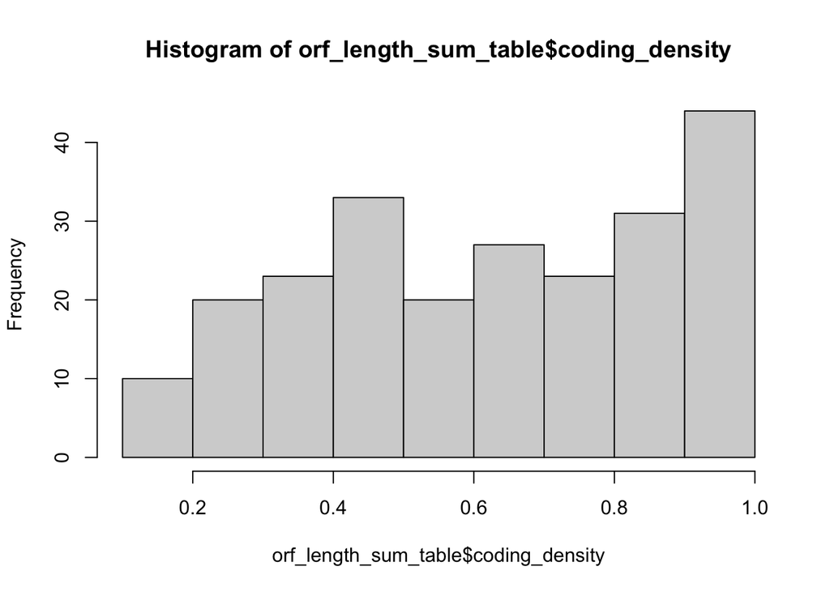

```r
hist(orf_length_sum_table$coding_density)
```

```r
sum(orf_length_sum_table$coding_density==-Inf)
```

```
## [1] 9
```

```r
to_remove_low_coding_density=c(orf_length_sum_table$contig[orf_length_sum_table$coding_density<0.5],
orf_length_sum_table$contig[orf_length_sum_table$coding_density==-Inf])
to_remove_low_coding_density
```

```
##   [1] "contig_10044" "contig_10174" "contig_10368" "contig_10846" "contig_11146"
##   [6] "contig_11337" "contig_11431" "contig_11463" "contig_11477" "contig_11563"
##  [11] "contig_11569" "contig_11976" "contig_12189" "contig_12349" "contig_12666"
##  [16] "contig_12998" "contig_13007" "contig_13047" "contig_13195" "contig_13400"
##  [21] "contig_14147" "contig_14497" "contig_14641" "contig_14664" "contig_14873"
##  [26] "contig_15123" "contig_15364" "contig_15413" "contig_15428" "contig_15862"
##  [31] "contig_15870" "contig_15940" "contig_15966" "contig_16355" "contig_16748"
##  [36] "contig_16750" "contig_16776" "contig_16951" "contig_17050" "contig_17064"
##  [41] "contig_17159" "contig_17350" "contig_17652" "contig_17783" "contig_17805"
##  [46] "contig_18053" "contig_18437" "contig_18861" "contig_19023" "contig_19184"
##  [51] "contig_19542" "contig_19673" "contig_19767" "contig_19872" "contig_20122"
##  [56] "contig_20213" "contig_20269" "contig_20579" "contig_21020" "contig_2115"
##  [61] "contig_21183" "contig_21780" "contig_22020" "contig_22023" "contig_23120"
##  [66] "contig_2569"  "contig_2972"  "contig_3152"  "contig_3929"  "contig_4009"
##  [71] "contig_4330"  "contig_4891"  "contig_5123"  "contig_5390"  "contig_6572"
##  [76] "contig_6743"  "contig_7225"  "contig_7322"  "contig_7466"  "contig_7472"
##  [81] "contig_7477"  "contig_7483"  "contig_7496"  "contig_8211"  "contig_8390"
##  [86] "contig_8457"  "contig_8464"  "contig_8761"  "contig_9174"  "contig_9193"
##  [91] "contig_9219"  "contig_9232"  "contig_9272"  "contig_9358"  "contig_9638"
##  [96] "contig_10368" "contig_11569" "contig_14147" "contig_16748" "contig_18053"
## [101] "contig_19184" "contig_20122" "contig_5123"  "contig_6572"
```

```r
# move rownames to column and vice versa
library(tibble)
wga_table2 <-wga_table %>% rownames_to_column('contig_name')
wga_table2 = filter(wga_table2, !contig_name %in% to_remove_low_coding_density)
wga_table2<-wga_table2 %>% column_to_rownames('contig_name')

wta_table2<-wta_table %>% rownames_to_column('contig_name')
wta_table2 = filter(wta_table2, !contig_name %in% to_remove_low_coding_density)
wta_table2<-wta_table2 %>% column_to_rownames('contig_name')
```

# write final tables to disk

## WGA dataset

```r
# contig 18555 is in fact a subset of contig_15192. To deal with this issue, I summed the values obtained for both contigs:
sum=apply(X = wga_table2[which(rownames(wga_table2) %in% c("contig_18555" ,"contig_15192")),1:56], MARGIN = 2, sum)
wga_table2["contig_15192",1:56]=sum
wga_table2=wga_table2[-which(rownames(wga_table2) == "contig_18555"),] # remove contig_18555

################################
# create a barplot for each sample
################################
tab=wga_table2[,1:57]
rownames(tab)=rownames(wga_table2)
tab=tab[,order(names(tab))]

# import a table indicating the number of reads mapped per contig and sample
tab2=read.table("/Users/jvaraldi/Documents/Manips/Viromics_Metagenomics/Snakemake/bam_wgawta_samples/bams/nreads_mapped3.txt", h=T)
infos2=read.table("/Users/jvaraldi/Documents/Manips/Viromics_Metagenomics/Snakemake/TABLES/infos2.txt", comment.char = "", header = T, fill=T, sep="\t")
rownames(tab2)=tab2$Contig
tab2=tab2[,-which(names(tab2) == "Contig")]

# subset to rows (contigs) present in tab table
row_match_idx=match(rownames(tab), rownames(tab2))
tab2_row_ordered=tab2[row_match_idx,]

# subset to cols (samples) present in tab table
name_match_idx=match(colnames(tab2_row_ordered), infos2$x)
colnames(tab2_row_ordered)=infos2$short_name[name_match_idx]
# replace + by . in a few names
names(tab2_row_ordered) = sub(pattern = "\\+", replacement = ".", x = colnames(tab2_row_ordered))
names(tab2_row_ordered) = sub(pattern = "H2O__NA__WTA", replacement = "control", x = colnames(tab2_row_ordered))
col_match_idx=match(colnames(tab), colnames(tab2_row_ordered))
tab2_row_col_ordered=tab2_row_ordered[,col_match_idx]

write.table(tab2_row_col_ordered, file = "../TABLES/wga_nreads_viruses_plus_unassigned.txt", col.names = TRUE, row.names = TRUE, quote=FALSE, sep="\t")

# plot the raw number of reads
pdf("../figures/mapping_wga/mapping_barplots_nreads_wga.pdf")
par(mar = c(5.1, 7.1, 4.1, 2.1))
for (i in 1:dim(tab2_row_col_ordered)[1]){
  barplot(as.matrix(tab2_row_col_ordered[rownames(tab2_row_col_ordered)==rownames(tab2_row_col_ordered)[i],]), las=1,
          cex.names = 0.3, main = rownames(tab2_row_col_ordered)[i], horiz = TRUE, xlab= "n reads mapped")
}
dev.off()
```

```r
# plot the coverage and the number of reads above bars
pdf("../figures/mapping_wga/mapping_barplots_wga.pdf")
par(mar = c(5.1, 7.1, 4.1, 2.1))
for (i in 1:dim(tab)[1]){
  y_pos=barplot(as.matrix(tab[rownames(tab)==rownames(tab)[i],]), las=1,
          cex.names = 0.3, main = rownames(tab)[i], horiz = TRUE, xlim=c(0,1.05), xlab="contig coverage")
  # add read numbers to the plot
  n_reads=t(tab2_row_col_ordered[rownames(tab2_row_col_ordered)==rownames(tab2_row_col_ordered)[i],])
  x_pos=t(tab[rownames(tab)==rownames(tab)[i],]+0.01)
  text=data.frame(x_pos, y_pos, n_reads)
  names(text)=c("xpos", "y_pos", "n_reads")
  text=text[-which(text$n_reads==0),]

  text(x = text$xpos
       , y = text$y_pos
       , text$n_reads, cex=0.3, col="grey77")
}
dev.off()
```

```r
################################

write.table(wga_table2, file = "../TABLES/wga_cov2_viruses_plus_unassigned_clean2.tab.txt", row.names = TRUE, col.names = TRUE, quote=FALSE, sep="\t")
```

## WTA dataset

```r
################################
# create a barplot for each sample
################################
tab=wta_table2[,1:57]
rownames(tab)=rownames(wta_table2)
tab=tab[,order(names(tab))]

# import a table indicating the number of reads mapped per contig and sample
tab2=read.table("/Users/jvaraldi/Documents/Manips/Viromics_Metagenomics/Snakemake/bam_wgawta_samples/bams/nreads_mapped3.txt", h=T)
infos2=read.table("/Users/jvaraldi/Documents/Manips/Viromics_Metagenomics/Snakemake/TABLES/infos2.txt", comment.char = "", header = T, fill=T, sep="\t")
rownames(tab2)=tab2$Contig
tab2=tab2[,-which(names(tab2) == "Contig")]

# subset to rows (contigs) present in tab table
row_match_idx=match(rownames(tab), rownames(tab2))
tab2_row_ordered=tab2[row_match_idx,]

# subset to cols (samples) present in tab table
name_match_idx=match(colnames(tab2_row_ordered), infos2$x)
colnames(tab2_row_ordered)=infos2$short_name[name_match_idx]
# replace + by . in a few names
names(tab2_row_ordered) = sub(pattern = "\\+", replacement = ".", x = colnames(tab2_row_ordered))
names(tab2_row_ordered) = sub(pattern = "H2O__NA__WGA", replacement = "control", x = colnames(tab2_row_ordered))
col_match_idx=match(colnames(tab), colnames(tab2_row_ordered))
tab2_row_col_ordered=tab2_row_ordered[,col_match_idx]

write.table(tab2_row_col_ordered, file = "../TABLES/wta_nreads_viruses_plus_unassigned.txt", col.names = TRUE, row.names = TRUE, quote=FALSE, sep="\t")

# plot the raw number of reads
pdf("../figures/mapping_wta/mapping_barplots_nreads_wta.pdf")
par(mar = c(5.1, 7.1, 4.1, 2.1))
for (i in 1:dim(tab2_row_col_ordered)[1]){
  barplot(as.matrix(tab2_row_col_ordered[rownames(tab2_row_col_ordered)==rownames(tab2_row_col_ordered)[i],]), las=1,
          cex.names = 0.3, main = rownames(tab2_row_col_ordered)[i], horiz = TRUE, xlab= "n reads mapped")
}
dev.off()
```

```r
# plot the coverage and the number of reads above bars
pdf("../figures/mapping_wta/mapping_barplots_wta.pdf")
par(mar = c(5.1, 7.1, 4.1, 2.1))
for (i in 1:dim(tab)[1]){
  y_pos=barplot(as.matrix(tab[rownames(tab)==rownames(tab)[i],]), las=1,
          cex.names = 0.3, main = rownames(tab)[i], horiz = TRUE, xlim=c(0,1.05), xlab="contig coverage")
  # add read numbers to the plot
  n_reads=t(tab2_row_col_ordered[rownames(tab2_row_col_ordered)==rownames(tab2_row_col_ordered)[i],])
  x_pos=t(tab[rownames(tab)==rownames(tab)[i],]+0.01)
  text=data.frame(x_pos, y_pos, n_reads)
  names(text)=c("xpos", "y_pos", "n_reads")
  text=text[-which(text$n_reads==0),]

  text(x = text$xpos
       , y = text$y_pos
       , text$n_reads, cex=0.3, col="grey77")
}
dev.off()
```

```r
################################

write.table(wta_table2, file = "../TABLES/wta_cov2_viruses_plus_unassigned2.tab.txt", row.names = TRUE, col.names = TRUE, quote=FALSE, sep="\t")
```

# Heatmaps

Merge all “Unclassified” entities (including sequences with no hits at all) as a single category :

```r
library(tidyr)
levels(wga_table2$family)
```

```
##  [1] "LbFV-like"                  "Parvoviridae"
##  [3] "Pithoviridae"               "Unclassified viruses"
##  [5] "Ackermannviridae"           "Anaplasmataceae"
##  [7] "Apidae"                     "Autographiviridae"
##  [9] "Bacteroidaceae"             "Baculoviridae"
## [11] "Chuviridae"                 "Dicistroviridae"
## [13] "Drexlerviridae"             "Drosophilidae"
## [15] "Enterobacteriaceae"         "Flaviviridae"
## [17] "Herelleviridae"             "Hominidae"
## [19] "Iflaviridae"                "Inoviridae"
## [21] "Lactobacillaceae"           "Metaviridae"
## [23] "Mycobacteriaceae"           "Myoviridae"
## [25] "Nodaviridae"                "Partitiviridae"
## [27] "Phasmaviridae"              "Phenuiviridae"
## [29] "Phycodnaviridae"            "Picornavirales"
## [31] "Plectroviridae"             "Podoviridae"
## [33] "Poxviridae"                 "Pteromalidae"
## [35] "Reoviridae"                 "Rhabdoviridae"
## [37] "Siphoviridae"               "Totiviridae"
## [39] "Unclassified DNA viruses"   "Unclassified dsRNA viruses"
## [41] "Unclassified RNA viruses"
```

```r
levels(wga_table2$family)[grep(pattern = "Unclassified", levels(wga_table2$family))]="Unclassified viruses"
# convert Nas to Unclassified
facna <- addNA(wga_table2$family)
levels(facna) <- c(levels(wga_table2$family), "Unclassified viruses")
wga_table2$family=facna
wga_table2$family=factor(wga_table2$family) # drop unused levels
```

```r
levels(wta_table2$family)
```

```
##  [1] "Chuviridae"                 "Dicistroviridae"
##  [3] "Flaviviridae"               "Iflaviridae"
##  [5] "Nodaviridae"                "Partitiviridae"
##  [7] "Phasmaviridae"              "Phenuiviridae"
##  [9] "Picornavirales"             "Reoviridae"
## [11] "Rhabdoviridae"              "Totiviridae"
## [13] "Unclassified viruses"       "Ackermannviridae"
## [15] "Anaplasmataceae"            "Apidae"
## [17] "Autographiviridae"          "Bacteroidaceae"
## [19] "Baculoviridae"              "Drexlerviridae"
## [21] "Drosophilidae"              "Enterobacteriaceae"
## [23] "Herelleviridae"             "Hominidae"
## [25] "Inoviridae"                 "Lactobacillaceae"
## [27] "LbFV-like"                  "Metaviridae"
## [29] "Mycobacteriaceae"           "Myoviridae"
## [31] "Parvoviridae"               "Phycodnaviridae"
## [33] "Pithoviridae"               "Plectroviridae"
## [35] "Podoviridae"                "Poxviridae"
## [37] "Pteromalidae"               "Siphoviridae"
## [39] "Unclassified DNA viruses"   "Unclassified dsRNA viruses"
## [41] "Unclassified RNA viruses"
```

```r
levels(wta_table2$family)[grep(pattern = "Unclassified", levels(wta_table2$family))]="Unclassified viruses"
# convert Nas to Unclassified
facna <- addNA(wta_table2$family)
levels(facna) <- c(levels(wta_table2$family), "Unclassified viruses")
wta_table2$family=facna
wta_table2$family=factor(wta_table2$family) # drop unused levels
```

remove 3 contigs that were initially considered as “dark matter”, but that were later identified as Wolbachia (based on a blastp done the 23 of februrary 2023, first hit deposited 09-NOV-2022) :

```r
wga_table2b=wga_table2[-which(rownames(wga_table2) %in% c("contig_18490", "contig_1179", "contig_19860")),]

# write table to disk
write.table(wga_table2b, "../TABLES/heatmap_cov_wga2_plus_unassigned2.pdf.txt", quote=FALSE)
dim(wga_table2b)
```

```
## [1] 47 65
```

## WGA

```
## [1] "no special row order"
## [1] "no special cols order"
```

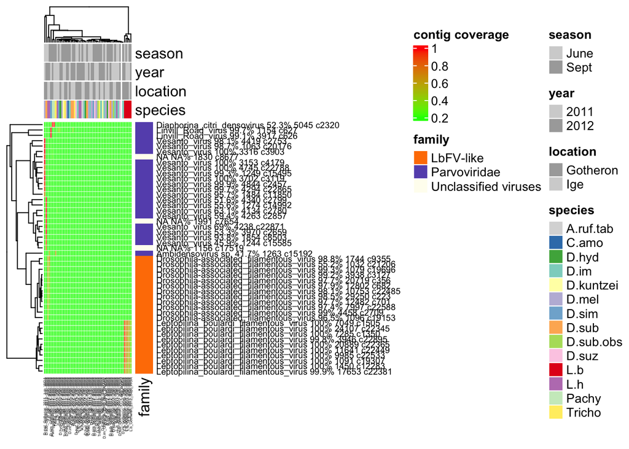

```r
plot_heatmap(mymatrix=wga_table2b, pdf="heatmap_cov_wga2_with_unassigned2.pdf", name="contig coverage", rowcex = 7, colour_code_viruses = d)
```

## WTA

```
## [1] "no special row order"
## [1] "no special cols order"
```

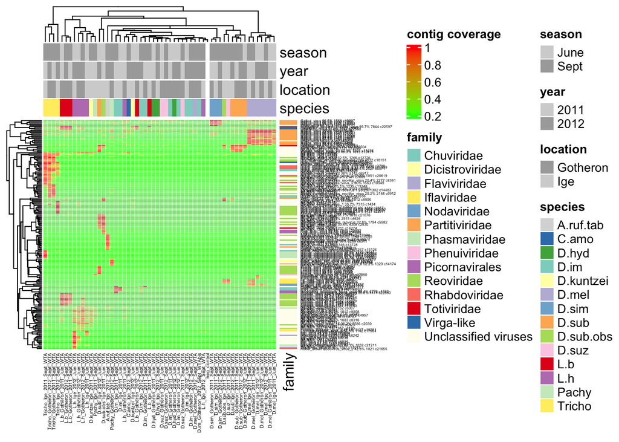

```r
# correct manually a few virus assignations
levels(wta_table2$family)=c(levels(wta_table2$family), "Virga-like")

wta_table2[grep("Reo", wta_table2$species, ignore.case = TRUE),]$family="Reoviridae"
wta_table2[grep("Saiwaicho", wta_table2$species, ignore.case = TRUE),]$family="Virga-like"
wta_table2[grep("virga", wta_table2$species, ignore.case = TRUE),]$family="Virga-like"
wta_table2[grep("Nora", wta_table2$species, ignore.case = TRUE),]$family="Picornavirales"
wta_table2[grep("tetragnatha", wta_table2$species, ignore.case = TRUE),]$family="Partitiviridae"

# import virus colour code:
d2=read.table("../TABLES/colour_code_virus_families.txt", header =TRUE, sep="\t", comment.char = "")

# reorder families
virus_fams <- ordered(wta_table2$family)
wta_table2$family <- ordered(virus_fams, levels = d$Family)

plot_heatmap(mymatrix=wta_table2,pdf="heatmap_cov_wta2_plus_unassigned2.pdf", name="contig coverage", rowcex = 3, colcex=4, colour_code_viruses = d2)
```

```r
# write table to disk
write.table(wta_table2, "../TABLES/heatmap_cov_wta2_plus_unassigned2.pdf.txt", quote=FALSE)
dim(wta_table2)
```

```
## [1] 192  65
```